# Instagram & NOAA Weather Data Aggregate Analysis

Damon Crockett

01/18/2015

## Aggregate, grouped by timestamps from the weather data

We have a dataset that joined NOAA weather data to IG data from NYC during Feb 26 - Aug 3, 2014. See this ipython notebook for a detailed look at the process of creating this dataset:

http://nbviewer.ipython.org/github/damoncrockett/SSI/blob/master/IGNOAA/scripts/NYC%20Instagram%20Weather.ipynb

```r
core = read.csv('/Users/damoncrockett/Dropbox/CALIT2DATA/IGNOAA/instagram_by_resolution.csv')
core$X = NULL
str(core)
```

```
## 'data.frame':    4488 obs. of  10 variables:
##  $ resolution   : Factor w/ 4488 levels "2014-02-25 22:51:00",..: 1 2 3 4 5 6 7 8 9 10 ...
##  $ temp         : num  27 27 26 26 27 27 27 27 26 26 ...
##  $ wind         : num  3 3 0 0 0 7 3 11 6 5 ...
##  $ precipitation: num  0 0 0 0 0 0 0 0 0.001 0 ...
##  $ sky          : num  0 0 0 0 0 1 1 1 1 1 ...
##  $ weekday      : int  2 2 3 3 3 3 3 3 3 3 ...
##  $ month        : int  2 2 2 2 2 2 2 2 2 2 ...
##  $ hour         : int  22 23 0 1 2 4 5 6 8 9 ...
##  $ count        : int  11 58 46 49 18 11 9 13 26 6 ...
##  $ date         : Factor w/ 160 levels "2014-02-25","2014-02-26",..: 1 1 2 2 2 2 2 2 2 2 ...
```

Let’s take a look at our response variable, ‘count’, which measures the number of IG posts made in the vicinity of Central Park, NYC, for a given hourly period. No IG post has more than 1 hour of error between its own timestamp and the weather timestamp.

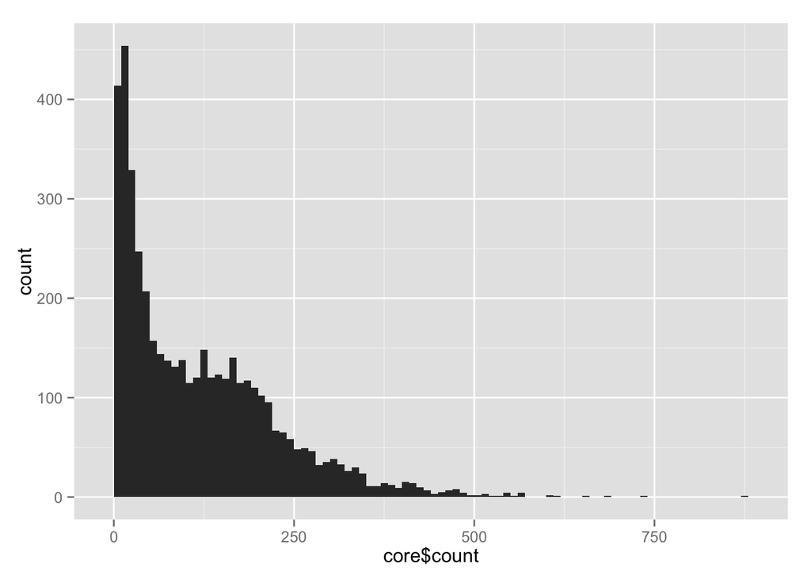

```r
library(ggplot2)
qplot(core$count, binwidth=10)
```

```r
summary(core$count)
```

```
##    Min. 1st Qu.  Median    Mean 3rd Qu.    Max.
##     1.0    27.0    92.0   117.6   181.0   872.0
```

```r
var(core$count)
```

```
## [1] 11504.61
```

The distribution of counts is not normal around the mean (118); this is typical for count data. We have a range from 1 to 872, we see a mode peak around 20, a steep dropoff after that, and a smooth descent to zero from about 50 onward to 700.

Because this is count data, it might make sense to use a Poisson regression model. However, our data is very ‘over-dispersed’, which means that the variance is higher than the mean, and so we’re better off using a negative binomial model (strictly speaking, it is the conditional means and variances that matter here, but overdispersion is so obvious in this case that it doesn’t matter).

# Weather Regressors

## Temperature

```r
library(MASS)
summary(glm.nb(data=core, count~temp))
```

```
##
## Call:
## glm.nb(formula = count ~ temp, data = core, init.theta = 1.022316319,
##     link = log)
##
## Deviance Residuals:
##     Min       1Q   Median       3Q      Max
## -2.6900  -1.1601  -0.2427   0.4610   2.8644
##
## Coefficients:
##              Estimate Std. Error z value Pr(>|z|)
## (Intercept) 4.0914637  0.0576905   70.92   <2e-16 ***
## temp        0.0111638  0.0009433   11.84   <2e-16 ***
## ---
## Signif. codes:  0 '***' 0.001 '**' 0.01 '*' 0.05 '.' 0.1 ' ' 1
##
## (Dispersion parameter for Negative Binomial(1.0223) family taken to be 1)
##
##     Null deviance: 5289.3  on 4487  degrees of freedom
## Residual deviance: 5137.3  on 4486  degrees of freedom
## AIC: 51665
##
## Number of Fisher Scoring iterations: 1
##
##
##               Theta:  1.0223
##           Std. Err.:  0.0195
##
##  2 x log-likelihood:  -51658.8410
```

[figure not shown]

```r
ggplot(core, aes(temp,count)) +
  geom_point(alpha=0.2) +
  stat_smooth(method=loess) +
  ylab('Average Hourly Instagram Post Count') +
  xlab('Temperature in Degrees Fahrenheit')
```

Temp is a significant regressor on count, and we can see from the graph that this is mostly because average hourly post counts increase sharply starting around 65 degrees Fahrenheit.

As a kind of aside: for the sort of research we’re doing here, p-values don’t matter that much. We have nearly 4,500 data points, and so statistical significance comes cheap. We are more interested in effect size, and really, you can usually see that with a plot. The models will be more useful when it comes to controlling for variables and finding relationships we can then plot, but I will continue to look at regression output just as a matter of procedural consistency. A further point: when we plot, we are plotting the raw data, not data from the fitted model. We could do the latter, but it’s a pain, so we’ll just keep that in mind when we’re looking at our plots.

## Wind

```r
summary(glm.nb(data=core, count~wind))
```

```
##
## Call:
## glm.nb(formula = count ~ wind, data = core, init.theta = 0.9989736444,
##     link = log)
##
## Deviance Residuals:
##     Min       1Q   Median       3Q      Max
## -2.6707  -1.1701  -0.2531   0.4520   2.9319
##
## Coefficients:
##             Estimate Std. Error z value Pr(>|z|)
## (Intercept) 4.660230   0.026546 175.554  < 2e-16 ***
## wind        0.020106   0.004193   4.795 1.62e-06 ***
## ---
## Signif. codes:  0 '***' 0.001 '**' 0.01 '*' 0.05 '.' 0.1 ' ' 1
##
## (Dispersion parameter for Negative Binomial(0.999) family taken to be 1)
##
##     Null deviance: 5171.6  on 4487  degrees of freedom
## Residual deviance: 5149.6  on 4486  degrees of freedom
## AIC: 51793
##
## Number of Fisher Scoring iterations: 1
##
##
##               Theta:  0.9990
##           Std. Err.:  0.0190
##
##  2 x log-likelihood:  -51786.8370
```

```r
exp(coef(glm.nb(data=core, count~wind)))
```

```
## (Intercept)        wind
##  105.660415    1.020309
```

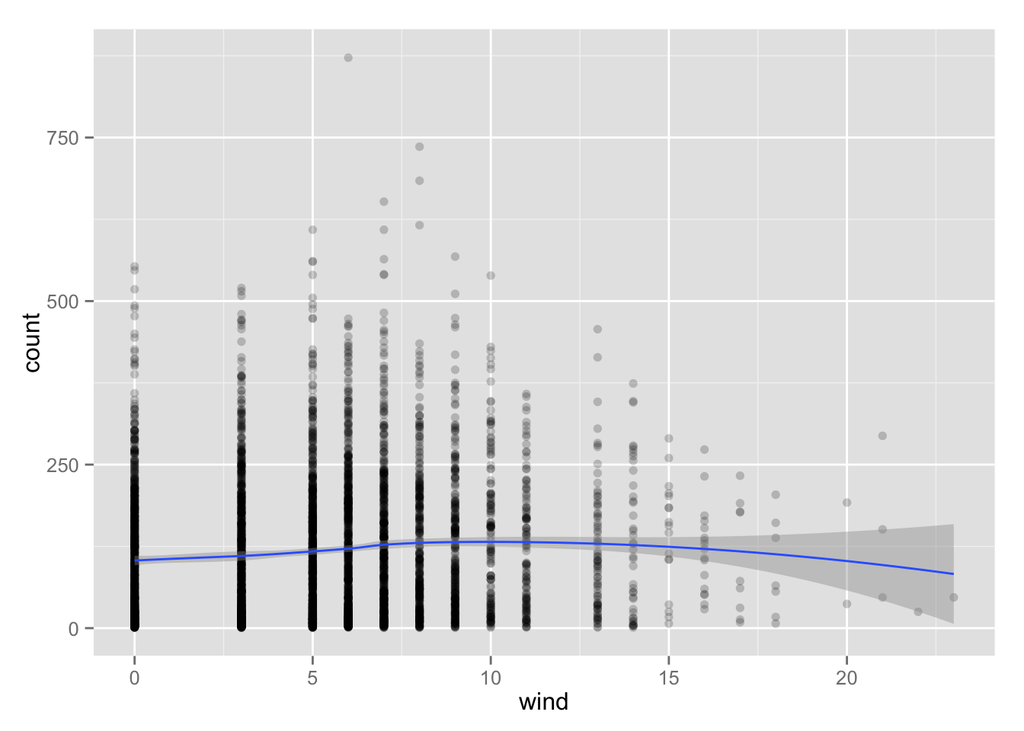

```r
ggplot(core, aes(wind,count)) +
  geom_point(alpha=0.2) +
  stat_smooth(method=loess)
```

Here is a perfect example of what I’m talking about: wind is a VERY significant regressor on post count, but the effect size is small, and the plot shows the relationship to be pretty uninteresting. Also, the relationship doesn’t look to be well-modeled by anything linear (it looks more quadratic).

## Sky (i.e., cloud cover)

```r
summary(glm.nb(data=core, count~factor(sky)))
```

```
##
## Call:
## glm.nb(formula = count ~ factor(sky), data = core, init.theta = 1.096455922,
##     link = log)
##
## Deviance Residuals:
##     Min       1Q   Median       3Q      Max
## -2.8013  -1.1040  -0.2213   0.3891   3.1120
##
## Coefficients:
##                   Estimate Std. Error z value Pr(>|z|)
## (Intercept)        5.02395    0.02261 222.205  < 2e-16 ***
## factor(sky)0.1875  0.03362    0.06660   0.505    0.614
## factor(sky)0.4375 -0.04440    0.06847  -0.649    0.517
## factor(sky)0.75   -0.21160    0.04948  -4.276  1.9e-05 ***
## factor(sky)1      -0.74128    0.03220 -23.023  < 2e-16 ***
## ---
## Signif. codes:  0 '***' 0.001 '**' 0.01 '*' 0.05 '.' 0.1 ' ' 1
##
## (Dispersion parameter for Negative Binomial(1.0965) family taken to be 1)
##
##     Null deviance: 5662.1  on 4487  degrees of freedom
## Residual deviance: 5101.1  on 4483  degrees of freedom
## AIC: 51286
##
## Number of Fisher Scoring iterations: 1
##
##
##               Theta:  1.0965
##           Std. Err.:  0.0211
##
##  2 x log-likelihood:  -51274.4580
```

[figure not shown]

```r
ggplot(core, aes(factor(sky),count)) +
  geom_boxplot() +
  ylab('Average Hourly Instagram Post Count') +
  xlab('Proportion of Sky Covered by Clouds')
```

This is somewhat more interesting. Let’s take a closer look:

```r
exp(coef(glm.nb(data=core, count~factor(sky))))
```

```
##       (Intercept) factor(sky)0.1875 factor(sky)0.4375   factor(sky)0.75
##       152.0111297         1.0341967         0.9565687         0.8092898
##      factor(sky)1
##         0.4765057
```

Clear and partly cloudy skies are not interestingly different (nor even are they significantly different, as the above regression output shows). However, once we have mostly cloudy and overcast skies, post counts drop. Post counts in overcast conditions are cut in half relative even to partly cloudy skies.

## Precipitation

```r
summary(glm.nb(data=core, count~precipitation))
```

```
##
## Call:
## glm.nb(formula = count ~ precipitation, data = core, init.theta = 1.0019729,
##     link = log)
##
## Deviance Residuals:
##     Min       1Q   Median       3Q      Max
## -2.6124  -1.1815  -0.2422   0.4600   2.9473
##
## Coefficients:
##               Estimate Std. Error z value Pr(>|z|)
## (Intercept)    4.77569    0.01511 315.995  < 2e-16 ***
## precipitation -2.17554    0.36156  -6.017 1.78e-09 ***
## ---
## Signif. codes:  0 '***' 0.001 '**' 0.01 '*' 0.05 '.' 0.1 ' ' 1
##
## (Dispersion parameter for Negative Binomial(1.002) family taken to be 1)
##
##     Null deviance: 5186.8  on 4487  degrees of freedom
## Residual deviance: 5148.2  on 4486  degrees of freedom
## AIC: 51776
##
## Number of Fisher Scoring iterations: 1
##
##
##               Theta:  1.0020
##           Std. Err.:  0.0191
##
##  2 x log-likelihood:  -51770.3610
```

```
## geom_smooth: method="auto" and size of largest group is >=1000, so using gam with formula: y ~ s(x, bs = "cs"). Use 'method = x' to change the smoothing method.
```

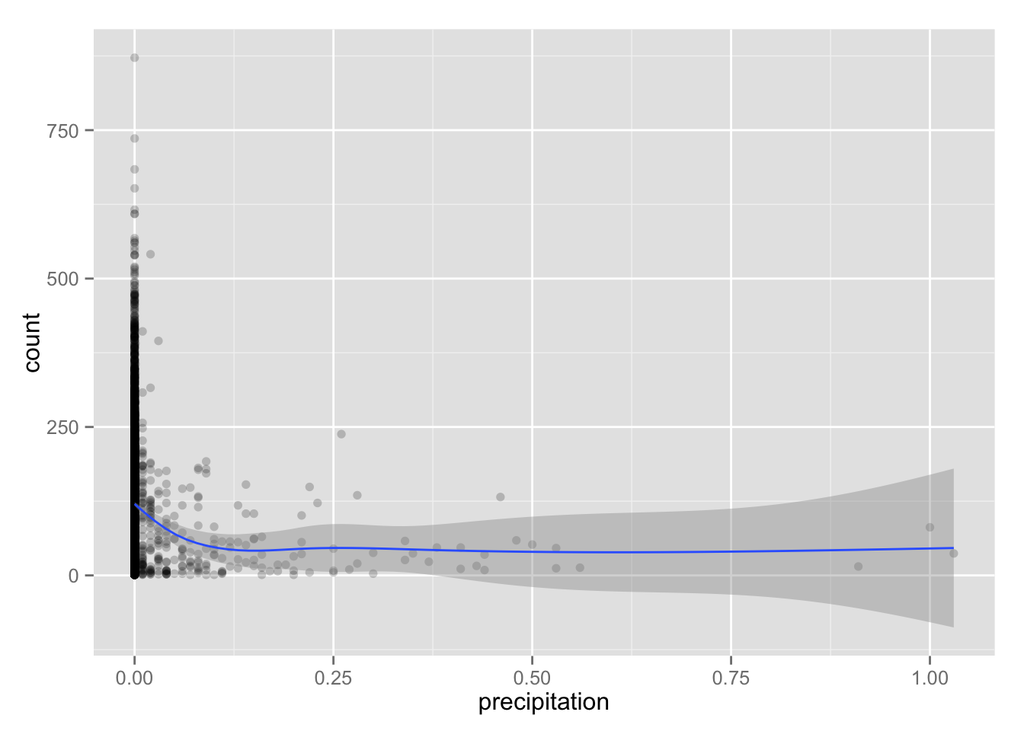

```r
ggplot(core, aes(precipitation,count)) +
  geom_point(alpha=0.2) +
  stat_smooth()
```

It looks as if post counts drop to half once it rains at least a tenth of an inch, but aren’t much affected by levels of rain above that. Let’s make a rain/no rain variable, and look at the difference in mean post counts:

```r
core$rain = core$precipitation > 0.0125
exp(coef(glm.nb(data=core, count~rain)))
```

```
## (Intercept)    rainTRUE
## 120.2734484   0.5150392
```

So, post count halves with rain above 0.0125 inches. Now, it’s tough to say exactly what that condition is like, since the rain measure is just an accumulated total for the hour. But we can see from this output that a condition this ‘extreme’ is pretty rare for any given hour period (4.5% of all hour periods):

```r
table(core$rain)
```

```
##
## FALSE  TRUE
##  4286   202
```

```r
length(core$rain[core$rain==1])/length(core$rain)
```

```
## [1] 0.04500891
```

Okay, so now we have some idea of the effects of weather on post count. We’ll revisit these later on, and control for various factors, but first, let’s look just at the IG data itself to find some trends.

# Instagram Patterns

**weekday**

```r
summary(glm.nb(data=core, count~factor(weekday)))
```

```
##
## Call:
## glm.nb(formula = count ~ factor(weekday), data = core, init.theta = 1.017563881,
##     link = log)
##
## Deviance Residuals:
##     Min       1Q   Median       3Q      Max
## -2.7549  -1.1703  -0.2161   0.4689   2.7477
##
## Coefficients:
##                  Estimate Std. Error z value Pr(>|z|)
## (Intercept)       4.79501    0.04078 117.591  < 2e-16 ***
## factor(weekday)2 -0.07232    0.05687  -1.272 0.203489
## factor(weekday)3 -0.18479    0.05556  -3.326 0.000881 ***
## factor(weekday)4 -0.21444    0.05512  -3.890 0.000100 ***
## factor(weekday)5 -0.11322    0.05595  -2.024 0.042997 *
## factor(weekday)6  0.08600    0.05674   1.516 0.129627
## factor(weekday)7  0.31370    0.05940   5.281 1.28e-07 ***
## ---
## Signif. codes:  0 '***' 0.001 '**' 0.01 '*' 0.05 '.' 0.1 ' ' 1
##
## (Dispersion parameter for Negative Binomial(1.0176) family taken to be 1)
##
##     Null deviance: 5265.3  on 4487  degrees of freedom
## Residual deviance: 5139.7  on 4481  degrees of freedom
## AIC: 51701
##
## Number of Fisher Scoring iterations: 1
##
##
##               Theta:  1.0176
##           Std. Err.:  0.0194
##
##  2 x log-likelihood:  -51684.5770
```

```r
exp(coef(glm.nb(data=core, count~factor(weekday))))
```

```
##      (Intercept) factor(weekday)2 factor(weekday)3 factor(weekday)4
##      120.9060403        0.9302321        0.8312774        0.8069956
## factor(weekday)5 factor(weekday)6 factor(weekday)7
##        0.8929497        1.0898062        1.3684726
```

Some interesting weekday trends. Let’s plot (the raw data, mind):

[figure not shown]

```r
ggplot(core, aes(factor(weekday), count)) + geom_boxplot() +
  ylab('Average Hourly Instagram Post Count') +
  xlab('Weekday')
```

A quadratic relationship, in fact (if we are treating weekday as a linear axis - a measure of ‘lateness-in-the-week’, perhaps). Note that Sunday (7) is the highest volume day; this is likely because there is lots of late-night Saturday posting, and Sunday takes the credit for anything after midnight.

Let’s look at weekdays vs. weekend days:

```r
core$weekend = core$weekday > 5
exp(coef(glm.nb(data=core,count~factor(weekend))))
```

```
##         (Intercept) factor(weekend)TRUE
##          107.318182            1.370494
```

The weekend mean is 137% of the weekday mean.

**hourly**

```r
summary(glm.nb(data=core,count~factor(hour)))
```

```
##
## Call:
## glm.nb(formula = count ~ factor(hour), data = core, init.theta = 2.36907397,
##     link = log)
##
## Deviance Residuals:
##     Min       1Q   Median       3Q      Max
## -4.1185  -0.8296  -0.0004   0.4589   3.5526
##
## Coefficients:
##                Estimate Std. Error z value Pr(>|z|)
## (Intercept)     4.26908    0.04754  89.809  < 2e-16 ***
## factor(hour)1  -0.54144    0.06718  -8.060 7.64e-16 ***
## factor(hour)2  -1.15372    0.06848 -16.848  < 2e-16 ***
## factor(hour)3  -1.65338    0.06900 -23.963  < 2e-16 ***
## factor(hour)4  -1.97264    0.07019 -28.105  < 2e-16 ***
## factor(hour)5  -1.72026    0.06882 -24.996  < 2e-16 ***
## factor(hour)6  -0.90475    0.06659 -13.587  < 2e-16 ***
## factor(hour)7  -0.09769    0.06755  -1.446  0.14808
## factor(hour)8   0.21422    0.06738   3.179  0.00148 **
## factor(hour)9   0.41630    0.06748   6.169 6.88e-10 ***
## factor(hour)10  0.58954    0.06734   8.755  < 2e-16 ***
## factor(hour)11  0.69733    0.06795  10.262  < 2e-16 ***
## factor(hour)12  0.95112    0.06878  13.828  < 2e-16 ***
## factor(hour)13  1.02120    0.07082  14.420  < 2e-16 ***
## factor(hour)14  1.19457    0.06982  17.109  < 2e-16 ***
## factor(hour)15  1.22086    0.06970  17.515  < 2e-16 ***
## factor(hour)16  1.13429    0.06844  16.574  < 2e-16 ***
## factor(hour)17  1.03123    0.06714  15.360  < 2e-16 ***
## factor(hour)18  0.99878    0.06826  14.631  < 2e-16 ***
## factor(hour)19  0.92611    0.06681  13.861  < 2e-16 ***
## factor(hour)20  0.79365    0.06792  11.684  < 2e-16 ***
## factor(hour)21  0.70564    0.06704  10.526  < 2e-16 ***
## factor(hour)22  0.50311    0.06667   7.546 4.49e-14 ***
## factor(hour)23  0.40012    0.06679   5.991 2.09e-09 ***
## ---
## Signif. codes:  0 '***' 0.001 '**' 0.01 '*' 0.05 '.' 0.1 ' ' 1
##
## (Dispersion parameter for Negative Binomial(2.3691) family taken to be 1)
##
##     Null deviance: 11866.7  on 4487  degrees of freedom
## Residual deviance:  4820.1  on 4464  degrees of freedom
## AIC: 47424
##
## Number of Fisher Scoring iterations: 1
##
##
##               Theta:  2.3691
##           Std. Err.:  0.0503
##
##  2 x log-likelihood:  -47373.9310
```

Lots of very significant effects of hour. Let’s plot this:

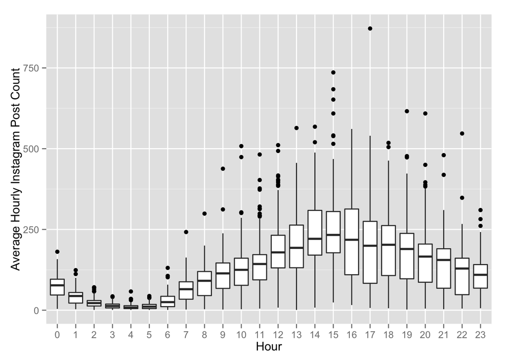

```r
ggplot(core, aes(factor(hour), count)) + geom_boxplot() +
  ylab('Average Hourly Instagram Post Count') +
  xlab('Hour')
```

As we might expect, posts drop to a trickle around 4am and peak in the afternoon/evening. Let’s see how this interacts with weekday:

[figure not shown]

```r
library(plyr)

by.weekday = ddply(core, c('weekday','hour'), summarize,
                   mean = mean(count))

ggplot(data=by.weekday, aes(x=factor(hour), y=mean, group=factor(weekday), color=factor(weekday))) +
  geom_line() +
  xlab('Hour') +
  ylab('Average Hourly Instagram Post Count') +
  scale_color_discrete(name="Weekday")
```

This is actually unexpected. I had thought that the high volume Sunday posting was due to lots of late-nite Saturday posts from bars. But in fact, Sunday has the highest volume all throughout the period from 10a til 11p. Saturday is a close-ish second, but Sunday is very clearly the winner. Tough to say why Sunday would beat Saturday even during ‘bar’ hours.

**monthly**

```r
summary(glm.nb(data=core,count~factor(month)))
```

```
##
## Call:
## glm.nb(formula = count ~ factor(month), data = core, init.theta = 1.00008051,
##     link = log)
##
## Deviance Residuals:
##     Min       1Q   Median       3Q      Max
## -2.6319  -1.1743  -0.2371   0.4610   2.8884
##
## Coefficients:
##                Estimate Std. Error z value Pr(>|z|)
## (Intercept)      4.4520     0.1154  38.589  < 2e-16 ***
## factor(month)3   0.3071     0.1206   2.547  0.01086 *
## factor(month)4   0.3817     0.1202   3.175  0.00150 **
## factor(month)5   0.3500     0.1200   2.918  0.00352 **
## factor(month)6   0.3177     0.1201   2.645  0.00817 **
## factor(month)7   0.2658     0.1206   2.203  0.02759 *
## factor(month)8  -0.1748     0.1661  -1.052  0.29263
## ---
## Signif. codes:  0 '***' 0.001 '**' 0.01 '*' 0.05 '.' 0.1 ' ' 1
##
## (Dispersion parameter for Negative Binomial(1.0001) family taken to be 1)
##
##     Null deviance: 5177.2  on 4487  degrees of freedom
## Residual deviance: 5149.0  on 4481  degrees of freedom
## AIC: 51797
##
## Number of Fisher Scoring iterations: 1
##
##
##               Theta:  1.0001
##           Std. Err.:  0.0190
##
##  2 x log-likelihood:  -51780.6580
```

```r
exp(coef(glm.nb(data=core,count~factor(month))))
```

```
##    (Intercept) factor(month)3 factor(month)4 factor(month)5 factor(month)6
##     85.8026316      1.3595346      1.4648095      1.4191197      1.3740292
## factor(month)7 factor(month)8
##      1.3044447      0.8396276
```

There are differences here. Let’s plot:

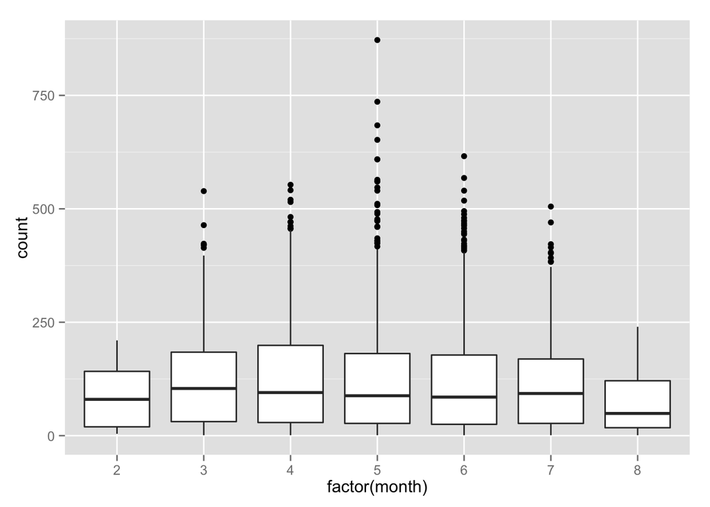

```r
ggplot(core, aes(factor(month), count)) + geom_boxplot()
```

Februrary and August look unusually low, and this is certainly explained by the fact there are only 3 recorded days in each of those months (our IG data is from Feb 26 to Aug 3). We must ignore those for the purposes of monthly trends, and since the middle 5 months look pretty uninteresting, we can drop this thread.

# Weather Regressors: Explanation

## Temperature

We know that posts go up when the weather hits 65, and they keep increasing as it gets hotter. What could explain this? Here’s some possibilities:

1. Time of day: people post less at night, and it’s colder at night.
2. Season: young people in school are very active on IG, and so probably drive a lot of activity on the site, and they post more during the summer when they are out of school. It’s warmer in summer.

### Time of Day

Okay, so let’s consider time of day. Remember our count by hour plot:

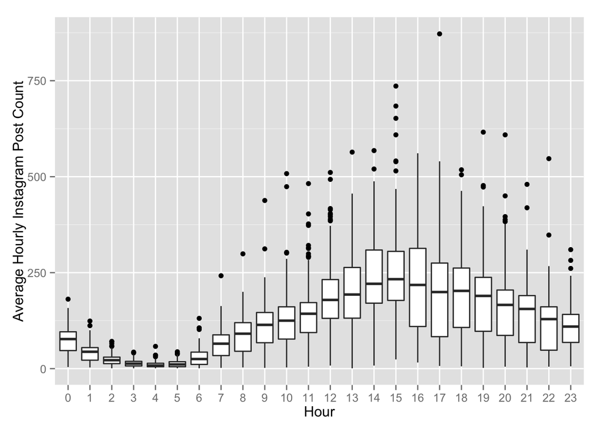

```r
ggplot(core, aes(factor(hour), count)) + geom_boxplot() +
  ylab('Average Hourly Instagram Post Count') +
  xlab('Hour')
```

Now let’s look at a plot of temperature by hour:

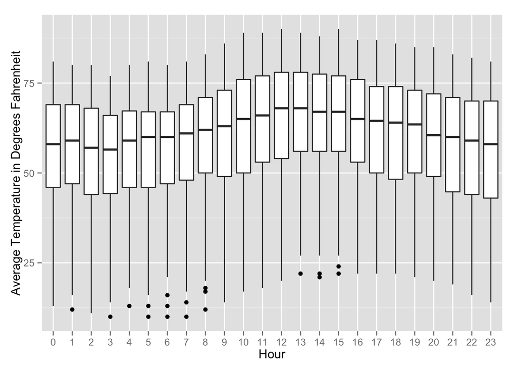

```r
ggplot(core, aes(factor(hour), temp)) + geom_boxplot() +
  ylab('Average Temperature in Degrees Fahrenheit') +
  xlab('Hour')
```

So, it’s hottest between noon and 3. Post counts are highest between 2 and 4. There is some overlap here, but clearly the effect of temperature on post count is not explained away by hour. We can see this in the plots, and verify it with an ANOVA:

```r
m0 = glm.nb(data=core, count~factor(hour))
m1 = glm.nb(data=core, count~factor(hour) + temp)
anova(m0,m1)
```

```
## Likelihood ratio tests of Negative Binomial Models
##
## Response: count
##                 Model    theta Resid. df    2 x log-lik.   Test    df
## 1        factor(hour) 2.369074      4464       -47373.93
## 2 factor(hour) + temp 2.384237      4463       -47345.58 1 vs 2     1
##   LR stat.      Pr(Chi)
## 1
## 2 28.35084 1.012027e-07
```

Temp is still a very significant regressor (p < 0.001) on post count, even after controlling for hour.

### Season

Let’s now consider the ‘school year’ explanation. According to that explanation, post counts increase when it’s hot because students are out of school, not because higher temperatures matter in themselves. In order for this explanation to work, it would have to be the case that summer months are hotter, and that post counts increase in the summer months. Let’s take a look:

```
## geom_smooth: method="auto" and size of largest group is >=1000, so using gam with formula: y ~ s(x, bs = "cs"). Use 'method = x' to change the smoothing method.
```

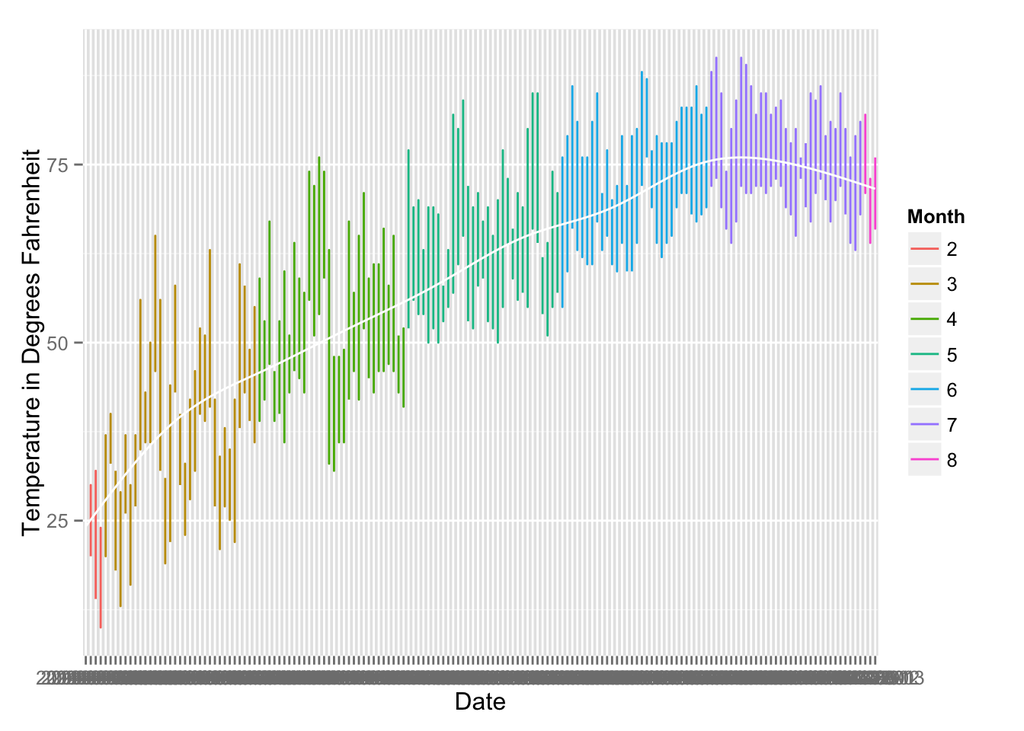

```r
ggplot(core, aes(factor(date), temp)) +
  geom_path(aes(color=factor(month))) +
  xlab('Date') +
  ylab('Temperature in Degrees Fahrenheit') +
  scale_color_discrete(name='Month') +
  stat_smooth(aes(group=1), color='white', se=F)
```

```
## geom_smooth: method="auto" and size of largest group is >=1000, so using gam with formula: y ~ s(x, bs = "cs"). Use 'method = x' to change the smoothing method.
```

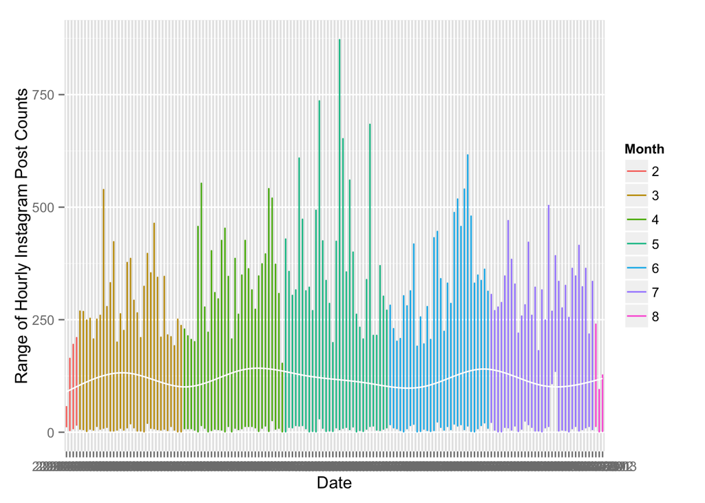

```r
ggplot(core, aes(factor(date), count)) +
  geom_path(aes(color=factor(month))) +
  xlab('Date') +
  ylab('Range of Hourly Instagram Post Counts') +
  scale_color_discrete(name='Month') +
  stat_smooth(aes(group=1), color='white', se=F)
```

This plot shows that it’s not even true that IG posting increases in summer. The white curve is a local estimate line that shows that, on average, post counts sort of undulate through the months. The highest peaks are in May, in fact, and there is a period of a couple days in July where the counts have a quite high floor, but beyond that, there is no evidence in favor of the ‘school year’ hypothesis.

An ANOVA will confirm:

```r
core$summer = core$month > 5
m0 = glm.nb(data=core, count~factor(summer))
m1 = glm.nb(data=core, count~factor(summer) + temp)
anova(m0,m1)
```

```
## Likelihood ratio tests of Negative Binomial Models
##
## Response: count
##                   Model     theta Resid. df    2 x log-lik.   Test    df
## 1        factor(summer) 0.9957361      4486       -51804.91
## 2 factor(summer) + temp 1.0604762      4485       -51457.29 1 vs 2     1
##   LR stat. Pr(Chi)
## 1
## 2 347.6146       0
```

Indeed, temperature is a significant regressor on count even after controlling for whether school is in session or not.

```r
m0 = glm.nb(data=core, count~factor(summer) * factor(hour))
m1 = glm.nb(data=core, count~factor(summer) * factor(hour) + temp)
anova(m0,m1)
```

```
## Likelihood ratio tests of Negative Binomial Models
##
## Response: count
##                                  Model    theta Resid. df    2 x log-lik.
## 1        factor(summer) * factor(hour) 2.384532      4440       -47343.84
## 2 factor(summer) * factor(hour) + temp 2.424259      4439       -47272.92
##     Test    df LR stat. Pr(Chi)
## 1
## 2 1 vs 2     1 70.91649       0
```

Finally, even if we control for both season and hour and any interactions between them, temp is still a significant regressor.

### aside…

As an aside, we should check what’s going on during those few days in July when post counts do not fall below ~110 or so. I’m guessing it’s something funky in the data. Let’s ‘zoom in’ on the plot:

```
## geom_smooth: method="auto" and size of largest group is <1000, so using loess. Use 'method = x' to change the smoothing method.
```

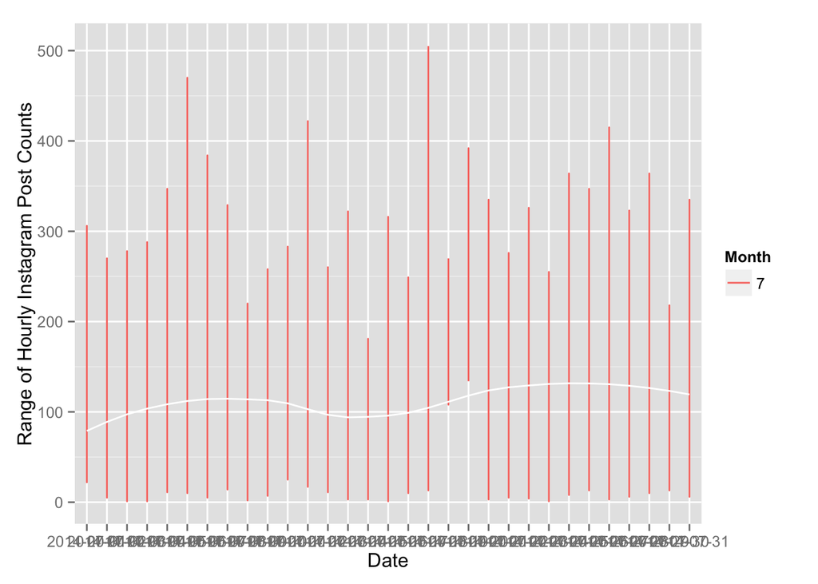

```r
ggplot(core[core$month==7,], aes(factor(date), count)) +
  geom_path(aes(color=factor(month))) +
  xlab('Date') +
  ylab('Range of Hourly Instagram Post Counts') +
  scale_color_discrete(name='Month') +
  stat_smooth(aes(group=1), color='white', se=F)
```

So, the dates are July 19 and 20. Let’s look:

```r
subset(core, core$date == '2014-07-19' | core$date == '2014-07-20')
```

```
##               resolution temp wind precipitation    sky weekday month hour
## 4131 2014-07-19 08:51:00   73    3             0 0.0000       6     7    8
## 4132 2014-07-19 09:51:00   75    6             0 0.0000       6     7    9
## 4133 2014-07-19 10:51:00   75    5             0 0.0000       6     7   10
## 4134 2014-07-19 11:51:00   76    7             0 0.0000       6     7   11
## 4135 2014-07-20 11:51:00   78    6             0 0.1875       7     7   11
## 4136 2014-07-20 13:51:00   78    3             0 0.1875       7     7   13
## 4137 2014-07-20 14:51:00   78    9             0 0.0000       7     7   14
## 4138 2014-07-20 15:51:00   76    9             0 0.0000       7     7   15
## 4139 2014-07-20 16:51:00   75    6             0 0.0000       7     7   16
## 4140 2014-07-20 17:51:00   74    6             0 0.0000       7     7   17
## 4141 2014-07-20 18:51:00   74    5             0 0.0000       7     7   18
## 4142 2014-07-20 19:51:00   72    3             0 0.0000       7     7   19
## 4143 2014-07-20 20:51:00   71    0             0 0.0000       7     7   20
## 4144 2014-07-20 21:51:00   70    0             0 0.0000       7     7   21
```

[output cut: 19 more lines]

### Back to temp…

Back to the temperature effect. We now have convincing evidence that temperature can affect the volume of posts on Instagram irrespective of time of day and season. Just for peace of mind, we can even look at some additional time-of-day variables. The rationale here is that a skeptic might still say:

“Post counts increase when the temperature is above 65. That’s just because whenever it’s that hot, people are awake, and so they post more. The high temperature is simply selecting a time of day that has high post volume for reasons unrelated to temperature.”

Well, we’ve already gone at least some of the way to showing that the skeptic is wrong, but we can test his hypothesis even more directly than we have yet:

```r
core$daylight = core$hour > 6 & core$hour < 19
core$waking = core$hour > 5 & core$hour < 23
core$high.volume.hours = core$hour > 9 & core$hour < 23
core$peak.hours = core$hour > 11 & core$hour < 20
m0 = glm.nb(data=core, count~daylight)
m1 = glm.nb(data=core, count~waking)
m2 = glm.nb(data=core, count~high.volume.hours)
m3 = glm.nb(data=core, count~peak.hours)
m4 = glm.nb(data=core, count~daylight + temp)
m5 = glm.nb(data=core, count~waking + temp)
m6 = glm.nb(data=core, count~high.volume.hours + temp)
m7 = glm.nb(data=core, count~peak.hours + temp)
anova(m0,m4)
```

```
## Likelihood ratio tests of Negative Binomial Models
##
## Response: count
##             Model    theta Resid. df    2 x log-lik.   Test    df LR stat.
## 1        daylight 1.137064      4486       -51077.85
## 2 daylight + temp 1.151956      4485       -51007.93 1 vs 2     1  69.9267
##        Pr(Chi)
## 1
## 2 1.110223e-16
```

```r
anova(m1,m5)
```

```
## Likelihood ratio tests of Negative Binomial Models
##
## Response: count
##           Model    theta Resid. df    2 x log-lik.   Test    df LR stat.
## 1        waking 1.331964      4486       -50235.57
## 2 waking + temp 1.345572      4485       -50183.59 1 vs 2     1 51.97716
##        Pr(Chi)
## 1
## 2 5.615508e-13
```

```r
anova(m2,m6)
```

```
## Likelihood ratio tests of Negative Binomial Models
##
## Response: count
##                      Model    theta Resid. df    2 x log-lik.   Test    df
## 1        high.volume.hours 1.420079      4486       -49910.62
## 2 high.volume.hours + temp 1.434641      4485       -49858.77 1 vs 2     1
##   LR stat.      Pr(Chi)
## 1
## 2  51.8441 6.008527e-13
```

```r
anova(m3,m7)
```

```
## Likelihood ratio tests of Negative Binomial Models
##
## Response: count
##               Model    theta Resid. df    2 x log-lik.   Test    df
## 1        peak.hours 1.216697      4486       -50717.35
## 2 peak.hours + temp 1.233673      4485       -50643.98 1 vs 2     1
##   LR stat. Pr(Chi)
## 1
## 2 73.36513       0
```

Still significant, even after considering the effect of daylight, waking hours, high volume hours, and peak hours. We can’t seem to suppress this effect by considering alternative hypotheses, so we can confidently say that temperature itself has an effect on Instagram activity - in Central Park, at least. We also know from our original plot that the effect of temperature is piece-wise linear: we don’t really see it below 65 F, but above that, there is a positive linear correlation between post volume and temperature.

Because of this, it’s tough to get a good estimate of the effect size. According to a model that includes hour, the effect of temperature looks like this:

```r
m = glm.nb(data=core, count~factor(hour) + temp)
exp(m$coef['temp'])
```

```
##     temp
## 1.003405
```

But we know that this is misleading, because the effect is piece-wise. We can run the model on a subset of the data above 65 degrees F, and we get this:

```r
m0 = glm.nb(data=core[core$temp > 65,], count~factor(hour))
m1 = glm.nb(data=core[core$temp > 65,], count~factor(hour) + temp)
m2 = glm.nb(data=core[core$temp > 65,], count~factor(hour) + factor(weekday) + factor(month) + sky + temp + rain + wind)
exp(m0$coef['temp'])
```

```
## <NA>
##   NA
```

```r
exp(m1$coef['temp'])
```

```
##     temp
## 1.013427
```

```r
exp(m2$coef['temp'])
```

```
##     temp
## 1.021619
```

```r
exp(m2$coef['temp'] * 20)
```

```
##     temp
## 1.533831
```

In the full model, in the subset of the data in which temp affects count, an increase from 66 F (our intercept) to 86 F means, on average, a 53% increase in hourly post count, regardless of which hour of the day we are in (although 86 F at night appears to be nonexistent in this dataset).

Finally, we can look at some potential interactions between temp and other variables:

```r
summary(glm.nb(data=core,count~daylight*temp))
```

```
##
## Call:
## glm.nb(formula = count ~ daylight * temp, data = core, init.theta = 1.152082499,
##     link = log)
##
## Deviance Residuals:
##     Min       1Q   Median       3Q      Max
## -2.9306  -1.1024  -0.3068   0.4527   3.3248
##
## Coefficients:
##                   Estimate Std. Error z value Pr(>|z|)
## (Intercept)       3.927274   0.075500  52.017  < 2e-16 ***
## daylightTRUE      0.671096   0.110534   6.071 1.27e-09 ***
## temp              0.006716   0.001290   5.205 1.94e-07 ***
## daylightTRUE:temp 0.001346   0.001805   0.745    0.456
## ---
## Signif. codes:  0 '***' 0.001 '**' 0.01 '*' 0.05 '.' 0.1 ' ' 1
##
## (Dispersion parameter for Negative Binomial(1.1521) family taken to be 1)
##
##     Null deviance: 5940.9  on 4487  degrees of freedom
## Residual deviance: 5077.9  on 4484  degrees of freedom
## AIC: 51017
##
## Number of Fisher Scoring iterations: 1
##
##
##               Theta:  1.1521
##           Std. Err.:  0.0224
##
##  2 x log-likelihood:  -51007.3260
```

```r
summary(glm.nb(data=core,count~waking*temp))
```

```
##
## Call:
## glm.nb(formula = count ~ waking * temp, data = core, init.theta = 1.351158097,
##     link = log)
##
## Deviance Residuals:
##     Min       1Q   Median       3Q      Max
## -3.1206  -1.0550  -0.2371   0.4379   3.5511
##
## Coefficients:
##                  Estimate Std. Error z value Pr(>|z|)
## (Intercept)     3.6761122  0.0908274  40.474  < 2e-16 ***
## wakingTRUE      0.8358597  0.1096479   7.623 2.48e-14 ***
## temp            0.0000615  0.0015800   0.039    0.969
## wakingTRUE:temp 0.0082439  0.0018591   4.434 9.23e-06 ***
## ---
## Signif. codes:  0 '***' 0.001 '**' 0.01 '*' 0.05 '.' 0.1 ' ' 1
##
## (Dispersion parameter for Negative Binomial(1.3512) family taken to be 1)
##
##     Null deviance: 6932.7  on 4487  degrees of freedom
## Residual deviance: 5006.8  on 4484  degrees of freedom
## AIC: 50172
##
## Number of Fisher Scoring iterations: 1
##
##
##               Theta:  1.3512
##           Std. Err.:  0.0268
##
##  2 x log-likelihood:  -50161.8400
```

```r
summary(glm.nb(data=core,count~high.volume.hours*temp))
```

```
##
## Call:
## glm.nb(formula = count ~ high.volume.hours * temp, data = core,
##     init.theta = 1.434828682, link = log)
##
## Deviance Residuals:
##     Min       1Q   Median       3Q      Max
## -3.2698  -1.0559  -0.1733   0.4300   3.9643
##
## Coefficients:
##                            Estimate Std. Error z value Pr(>|z|)
## (Intercept)                3.648576   0.070233  51.950  < 2e-16 ***
## high.volume.hoursTRUE      1.145294   0.099019  11.566  < 2e-16 ***
## temp                       0.005012   0.001203   4.167 3.09e-05 ***
## high.volume.hoursTRUE:temp 0.001294   0.001628   0.795    0.427
## ---
## Signif. codes:  0 '***' 0.001 '**' 0.01 '*' 0.05 '.' 0.1 ' ' 1
##
## (Dispersion parameter for Negative Binomial(1.4348) family taken to be 1)
##
##     Null deviance: 7346.7  on 4487  degrees of freedom
## Residual deviance: 4990.5  on 4484  degrees of freedom
## AIC: 49868
##
## Number of Fisher Scoring iterations: 1
##
##
##               Theta:  1.4348
##           Std. Err.:  0.0287
##
##  2 x log-likelihood:  -49858.0900
```

```r
summary(glm.nb(data=core,count~peak.hours*temp))
```

```
##
## Call:
## glm.nb(formula = count ~ peak.hours * temp, data = core, init.theta = 1.234291529,
##     link = log)
##
## Deviance Residuals:
##     Min       1Q   Median       3Q      Max
## -3.1063  -1.1179  -0.1555   0.4484   3.3491
##
## Coefficients:
##                      Estimate Std. Error z value Pr(>|z|)
## (Intercept)          3.877606   0.062620  61.923  < 2e-16 ***
## peak.hoursTRUE       1.123015   0.118478   9.479  < 2e-16 ***
## temp                 0.008124   0.001053   7.713 1.22e-14 ***
## peak.hoursTRUE:temp -0.002934   0.001876  -1.564    0.118
## ---
## Signif. codes:  0 '***' 0.001 '**' 0.01 '*' 0.05 '.' 0.1 ' ' 1
##
## (Dispersion parameter for Negative Binomial(1.2343) family taken to be 1)
##
##     Null deviance: 6351.6  on 4487  degrees of freedom
## Residual deviance: 5048.9  on 4484  degrees of freedom
## AIC: 50651
##
## Number of Fisher Scoring iterations: 1
##
##
##               Theta:  1.2343
##           Std. Err.:  0.0242
##
##  2 x log-likelihood:  -50641.3670
```

```r
summary(glm.nb(data=core,count~summer*temp))
```

```
##
## Call:
## glm.nb(formula = count ~ summer * temp, data = core, init.theta = 1.113425194,
##     link = log)
##
## Deviance Residuals:
##     Min       1Q   Median       3Q      Max
## -2.8138  -1.0934  -0.2551   0.4493   3.2382
##
## Coefficients:
##                  Estimate Std. Error z value Pr(>|z|)
## (Intercept)      3.913779   0.069820   56.05   <2e-16 ***
## summerTRUE      -5.470291   0.283658  -19.29   <2e-16 ***
## temp             0.016892   0.001342   12.58   <2e-16 ***
## summerTRUE:temp  0.068017   0.004002   17.00   <2e-16 ***
## ---
## Signif. codes:  0 '***' 0.001 '**' 0.01 '*' 0.05 '.' 0.1 ' ' 1
##
## (Dispersion parameter for Negative Binomial(1.1134) family taken to be 1)
##
##     Null deviance: 5747.2  on 4487  degrees of freedom
## Residual deviance: 5093.4  on 4484  degrees of freedom
## AIC: 51201
##
## Number of Fisher Scoring iterations: 1
##
##
##               Theta:  1.1134
##           Std. Err.:  0.0215
##
##  2 x log-likelihood:  -51190.9160
```

```r
summary(glm.nb(data=core,count~month*temp))
```

```
##
## Call:
## glm.nb(formula = count ~ month * temp, data = core, init.theta = 1.173439812,
##     link = log)
##
## Deviance Residuals:
##     Min       1Q   Median       3Q      Max
## -2.9537  -1.0591  -0.2499   0.4357   3.0074
##
## Coefficients:
##               Estimate Std. Error z value Pr(>|z|)
## (Intercept)  6.9989404  0.1856341  37.703   <2e-16 ***
## month       -1.2418905  0.0527871 -23.526   <2e-16 ***
## temp         0.0064162  0.0031935   2.009   0.0445 *
## month:temp   0.0111198  0.0007306  15.220   <2e-16 ***
## ---
## Signif. codes:  0 '***' 0.001 '**' 0.01 '*' 0.05 '.' 0.1 ' ' 1
##
## (Dispersion parameter for Negative Binomial(1.1734) family taken to be 1)
##
##     Null deviance: 6047.7  on 4487  degrees of freedom
## Residual deviance: 5068.5  on 4484  degrees of freedom
## AIC: 50918
##
## Number of Fisher Scoring iterations: 1
##
##
##               Theta:  1.1734
##           Std. Err.:  0.0228
##
##  2 x log-likelihood:  -50907.8250
```

```r
summary(glm.nb(data=core,count~weekday*temp))
```

```
##
## Call:
## glm.nb(formula = count ~ weekday * temp, data = core, init.theta = 1.029836518,
##     link = log)
##
## Deviance Residuals:
##     Min       1Q   Median       3Q      Max
## -2.7054  -1.1617  -0.2224   0.4775   2.6755
##
## Coefficients:
##               Estimate Std. Error z value Pr(>|z|)
## (Intercept)  4.0310890  0.1261927  31.944  < 2e-16 ***
## weekday      0.0131366  0.0304417   0.432    0.666
## temp         0.0091024  0.0020360   4.471 7.79e-06 ***
## weekday:temp 0.0005389  0.0004930   1.093    0.274
## ---
## Signif. codes:  0 '***' 0.001 '**' 0.01 '*' 0.05 '.' 0.1 ' ' 1
##
## (Dispersion parameter for Negative Binomial(1.0298) family taken to be 1)
##
##     Null deviance: 5327.2  on 4487  degrees of freedom
## Residual deviance: 5133.4  on 4484  degrees of freedom
## AIC: 51628
##
## Number of Fisher Scoring iterations: 1
##
##
##               Theta:  1.0298
##           Std. Err.:  0.0197
##
##  2 x log-likelihood:  -51618.4040
```

There is an interaction between temp and waking hours, and temp and summer, as well as temp and month (these could be the same thing). Let’s look at this:

```
## geom_smooth: method="auto" and size of largest group is <1000, so using loess. Use 'method = x' to change the smoothing method.
```

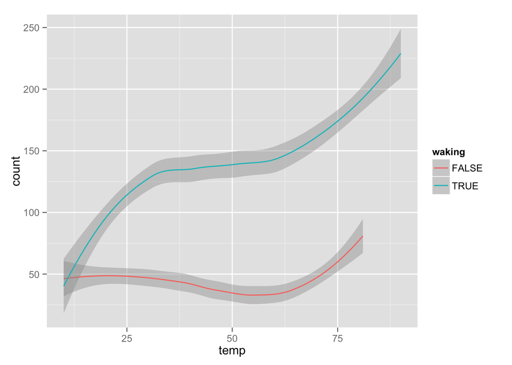

```r
by.waking = ddply(core, c('waking','temp'), summarize,
                   count = mean(count))

ggplot(data=by.waking, aes(x=temp, y=count, group=waking, color=waking)) +
  stat_smooth()
```

The effect of temp on count is much more pronounced during waking hours, which we might expect, especially since our temp effect really only applies when it’s very warm.

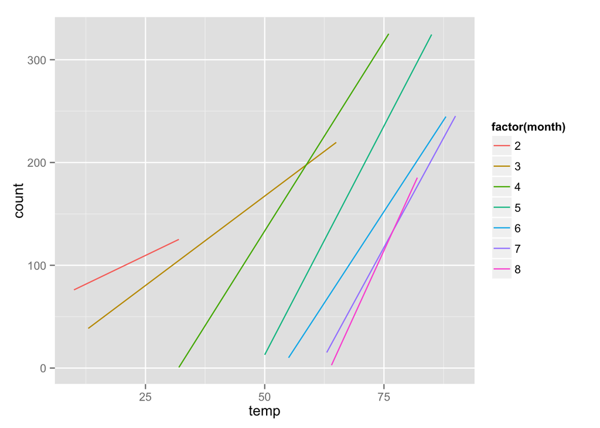

```r
by.month = ddply(core, c('month','temp'), summarize,
                   count = mean(count))

ggplot(data=by.month, aes(x=temp, y=count, group=factor(month), color=factor(month))) +
  stat_smooth(se=F,method=lm)
```

Ok I’ve sort of fudged the graph to be more readable; what we’re seeing here is that the effect of temp on count is more pronounced in the warmer months. This makes sense, since the effect is only seen above 65 F. Thus, the months that spend more time in this range will see the effect more often.

## Precipitation

When it rains, people post less. But is this because of the rain? Let’s consider some potential confounding variables.

We wouldn’t expect rain to be correlated with things like hour and weekday, but let’s see:

```r
library(gmodels)
CrossTable(core$hour, core$rain, expected=TRUE)
```

```
##
##
##    Cell Contents
## |-------------------------|
## |                       N |
## |              Expected N |
## | Chi-square contribution |
## |           N / Row Total |
## |           N / Col Total |
## |         N / Table Total |
## |-------------------------|
##
##
## Total Observations in Table:  4488
##
##
##              | core$rain
##    core$hour |     FALSE |      TRUE | Row Total |
## -------------|-----------|-----------|-----------|
##            0 |       182 |        11 |       193 |
##              |   184.313 |     8.687 |           |
##              |     0.029 |     0.616 |           |
##              |     0.943 |     0.057 |     0.043 |
##              |     0.042 |     0.054 |           |
##              |     0.041 |     0.002 |           |
## -------------|-----------|-----------|-----------|
##            1 |       191 |         7 |       198 |
##              |   189.088 |     8.912 |           |
##              |     0.019 |     0.410 |           |
##              |     0.965 |     0.035 |     0.044 |
##              |     0.045 |     0.035 |           |
##              |     0.043 |     0.002 |           |
## -------------|-----------|-----------|-----------|
##            2 |       185 |         7 |       192 |
##              |   183.358 |     8.642 |           |
##              |     0.015 |     0.312 |           |
##              |     0.964 |     0.036 |     0.043 |
##              |     0.043 |     0.035 |           |
##              |     0.041 |     0.002 |           |
## -------------|-----------|-----------|-----------|
```

[output cut: 146 more lines]

```
## -------------|-----------|-----------|-----------|
## Column Total |      4286 |       202 |      4488 |
##              |     0.955 |     0.045 |           |
## -------------|-----------|-----------|-----------|
##
##
## Statistics for All Table Factors
##
##
## Pearson's Chi-squared test
## ------------------------------------------------------------
## Chi^2 =  28.06675     d.f. =  23     p =  0.213268
##
##
##
```

```r
CrossTable(core$weekday, core$rain, expected=TRUE)
```

```
##
##
##    Cell Contents
## |-------------------------|
## |                       N |
## |              Expected N |
## | Chi-square contribution |
## |           N / Row Total |
## |           N / Col Total |
## |         N / Table Total |
## |-------------------------|
##
##
## Total Observations in Table:  4488
##
##
##              | core$rain
## core$weekday |     FALSE |      TRUE | Row Total |
## -------------|-----------|-----------|-----------|
##            1 |       568 |        28 |       596 |
##              |   569.175 |    26.825 |           |
##              |     0.002 |     0.051 |           |
##              |     0.953 |     0.047 |     0.133 |
##              |     0.133 |     0.139 |           |
##              |     0.127 |     0.006 |           |
## -------------|-----------|-----------|-----------|
##            2 |       608 |        23 |       631 |
##              |   602.599 |    28.401 |           |
##              |     0.048 |     1.027 |           |
##              |     0.964 |     0.036 |     0.141 |
##              |     0.142 |     0.114 |           |
##              |     0.135 |     0.005 |           |
## -------------|-----------|-----------|-----------|
##            3 |       653 |        44 |       697 |
##              |   665.629 |    31.371 |           |
##              |     0.240 |     5.084 |           |
##              |     0.937 |     0.063 |     0.155 |
##              |     0.152 |     0.218 |           |
##              |     0.145 |     0.010 |           |
## -------------|-----------|-----------|-----------|
```

[output cut: 27 more lines]

```
## -------------|-----------|-----------|-----------|
## Column Total |      4286 |       202 |      4488 |
##              |     0.955 |     0.045 |           |
## -------------|-----------|-----------|-----------|
##
##
## Statistics for All Table Factors
##
##
## Pearson's Chi-squared test
## ------------------------------------------------------------
## Chi^2 =  23.83134     d.f. =  6     p =  0.0005609046
##
##
##
```

Okay, that’s strange. Rain and weekday appear not to be independent in our dataset. It rains less on Sundays than we would expect if the variables were independent. This could matter, actually, because we saw that Sunday has the highest posting volume of any day, and so if it rains less on those days, that could drive some of this effect. Let’s see:

```r
core$sunday = core$weekday == 7
m0 = glm.nb(data=core, count~sunday)
m1 = glm.nb(data=core, count~sunday+rain)
anova(m0,m1)
```

```
## Likelihood ratio tests of Negative Binomial Models
##
## Response: count
##           Model    theta Resid. df    2 x log-lik.   Test    df LR stat.
## 1        sunday 1.009654      4486       -51727.84
## 2 sunday + rain 1.021180      4485       -51664.79 1 vs 2     1 63.04294
##        Pr(Chi)
## 1
## 2 1.998401e-15
```

Okay, the rain regressor is significant over and above what is accounted for by its being Sunday.

We might think rain is correlated with a ‘seasonal’ variable (like winter, spring, summer), but if it is, it’s also likely going to be part of any explanation involving that season. So if a ‘rainy’ season (like spring?) has an effect on posts, then rain has an effect on posts. But is rain even correlated with season?

```r
CrossTable(core$month, core$rain, expected=TRUE)
```

```
##
##
##    Cell Contents
## |-------------------------|
## |                       N |
## |              Expected N |
## | Chi-square contribution |
## |           N / Row Total |
## |           N / Col Total |
## |         N / Table Total |
## |-------------------------|
##
##
## Total Observations in Table:  4488
##
##
##              | core$rain
##   core$month |     FALSE |      TRUE | Row Total |
## -------------|-----------|-----------|-----------|
##            2 |        76 |         0 |        76 |
##              |    72.579 |     3.421 |           |
##              |     0.161 |     3.421 |           |
##              |     1.000 |     0.000 |     0.017 |
##              |     0.018 |     0.000 |           |
##              |     0.017 |     0.000 |           |
## -------------|-----------|-----------|-----------|
##            3 |       788 |        33 |       821 |
##              |   784.048 |    36.952 |           |
##              |     0.020 |     0.423 |           |
##              |     0.960 |     0.040 |     0.183 |
##              |     0.184 |     0.163 |           |
##              |     0.176 |     0.007 |           |
## -------------|-----------|-----------|-----------|
##            4 |       819 |        59 |       878 |
##              |   838.482 |    39.518 |           |
##              |     0.453 |     9.605 |           |
##              |     0.933 |     0.067 |     0.196 |
##              |     0.191 |     0.292 |           |
##              |     0.182 |     0.013 |           |
## -------------|-----------|-----------|-----------|
```

[output cut: 27 more lines]

```
## -------------|-----------|-----------|-----------|
## Column Total |      4286 |       202 |      4488 |
##              |     0.955 |     0.045 |           |
## -------------|-----------|-----------|-----------|
##
##
## Statistics for All Table Factors
##
##
## Pearson's Chi-squared test
## ------------------------------------------------------------
## Chi^2 =  18.31243     d.f. =  6     p =  0.005497063
##
##
##
```

Looks like rain is correlated with April. It rains more in April than you’d expect if rain and month were independent (and perhaps a little less in June and July). Let’s look at some ANOVAs:

```r
core$april = core$month == 4
m0 = glm.nb(data=core,count~month)
m1 = glm.nb(data=core,count~april)
m2 = glm.nb(data=core,count~month+rain)
m3 = glm.nb(data=core,count~april+rain)
anova(m0,m2)
```

```
## Likelihood ratio tests of Negative Binomial Models
##
## Response: count
##          Model     theta Resid. df    2 x log-lik.   Test    df LR stat.
## 1        month 0.9954365      4486       -51806.58
## 2 month + rain 1.0080149      4485       -51736.63 1 vs 2     1 69.94764
##        Pr(Chi)
## 1
## 2 1.110223e-16
```

```r
anova(m1,m3)
```

```
## Likelihood ratio tests of Negative Binomial Models
##
## Response: count
##          Model     theta Resid. df    2 x log-lik.   Test    df LR stat.
## 1        april 0.9959037      4486       -51803.97
## 2 april + rain 1.0085998      4485       -51733.43 1 vs 2     1 70.53946
##   Pr(Chi)
## 1
## 2       0
```

Rain is a significant regressor over and above both month and April.

```r
summary(glm.nb(data=core, count~april))
```

```
##
## Call:
## glm.nb(formula = count ~ april, data = core, init.theta = 0.9959036786,
##     link = log)
##
## Deviance Residuals:
##     Min       1Q   Median       3Q      Max
## -2.6269  -1.1861  -0.2394   0.4550   2.9915
##
## Coefficients:
##             Estimate Std. Error z value Pr(>|z|)
## (Intercept)  4.75095    0.01675 283.649   <2e-16 ***
## aprilTRUE    0.08283    0.03786   2.188   0.0287 *
## ---
## Signif. codes:  0 '***' 0.001 '**' 0.01 '*' 0.05 '.' 0.1 ' ' 1
##
## (Dispersion parameter for Negative Binomial(0.9959) family taken to be 1)
##
##     Null deviance: 5156.2  on 4487  degrees of freedom
## Residual deviance: 5151.3  on 4486  degrees of freedom
## AIC: 51810
##
## Number of Fisher Scoring iterations: 1
##
##
##               Theta:  0.9959
##           Std. Err.:  0.0190
##
##  2 x log-likelihood:  -51803.9700
```

And anyway, it turns out that people actually post *more* in April despite posting less on average as it rains more (in any month). So, there’s nothing about season that’s going to help here.

We also know that wind is not interestingly connected with post count, so it can’t be that. What about temp? Well it probably is colder when raining, and fewer post as it gets colder. That could perhaps explain the effect. Let’s consider adding rain to a model already containing temp:

```r
m0 = glm.nb(data=core,count~temp)
m1 = glm.nb(data=core,count~temp+rain)
anova(m0,m1)
```

```
## Likelihood ratio tests of Negative Binomial Models
##
## Response: count
##         Model    theta Resid. df    2 x log-lik.   Test    df LR stat.
## 1        temp 1.022316      4486       -51658.84
## 2 temp + rain 1.033953      4485       -51596.19 1 vs 2     1 62.65396
##        Pr(Chi)
## 1
## 2 2.442491e-15
```

Precipitation is a significant regressor even controlling for temp. Okay, now the biggie: what about sky?

```r
CrossTable(factor(core$sky), core$rain, expected=TRUE)
```

```
##
##
##    Cell Contents
## |-------------------------|
## |                       N |
## |              Expected N |
## | Chi-square contribution |
## |           N / Row Total |
## |           N / Col Total |
## |         N / Table Total |
## |-------------------------|
##
##
## Total Observations in Table:  4488
##
##
##                  | core$rain
## factor(core$sky) |     FALSE |      TRUE | Row Total |
## -----------------|-----------|-----------|-----------|
##                0 |      1795 |         2 |      1797 |
##                  |  1716.119 |    80.881 |           |
##                  |     3.626 |    76.930 |           |
##                  |     0.999 |     0.001 |     0.400 |
##                  |     0.419 |     0.010 |           |
##                  |     0.400 |     0.000 |           |
## -----------------|-----------|-----------|-----------|
##           0.1875 |       231 |         3 |       234 |
##                  |   223.468 |    10.532 |           |
##                  |     0.254 |     5.387 |           |
##                  |     0.987 |     0.013 |     0.052 |
##                  |     0.054 |     0.015 |           |
##                  |     0.051 |     0.001 |           |
## -----------------|-----------|-----------|-----------|
##           0.4375 |       213 |         7 |       220 |
##                  |   210.098 |     9.902 |           |
##                  |     0.040 |     0.850 |           |
##                  |     0.968 |     0.032 |     0.049 |
##                  |     0.050 |     0.035 |           |
##                  |     0.047 |     0.002 |           |
## -----------------|-----------|-----------|-----------|
```

[output cut: 13 more lines]

```
## -----------------|-----------|-----------|-----------|
##     Column Total |      4286 |       202 |      4488 |
##                  |     0.955 |     0.045 |           |
## -----------------|-----------|-----------|-----------|
##
##
## Statistics for All Table Factors
##
##
## Pearson's Chi-squared test
## ------------------------------------------------------------
## Chi^2 =  213.2063     d.f. =  4     p =  5.428396e-45
##
##
##
```

There is, of course, a very strong correlation between rain and sky. When the sky is clear, it’s almost never raining, and when it’s completely overcast, it’s often raining. We haven’t looked in detail at the effect of sky on post count, but we can do an ANOVA with sky and rain here.

```r
m0 = glm.nb(data=core,count~factor(sky))
m1 = glm.nb(data=core,count~factor(sky)+rain)
m2 = glm.nb(data=core,count~rain)
anova(m0,m1)
```

```
## Likelihood ratio tests of Negative Binomial Models
##
## Response: count
##                Model    theta Resid. df    2 x log-lik.   Test    df
## 1        factor(sky) 1.096456      4483       -51274.46
## 2 factor(sky) + rain 1.099428      4482       -51259.66 1 vs 2     1
##   LR stat.      Pr(Chi)
## 1
## 2 14.79638 0.0001197651
```

Rain is significant, even controlling for sky.

```r
exp(m1$coef['rainTRUE'])
```

```
##  rainTRUE
## 0.7530677
```

```r
exp(m2$coef['rainTRUE'])
```

```
##  rainTRUE
## 0.5150392
```

However, adding sky to the model decreases the effect of rain on post volume. Without sky in the model, rain reduces post volume by half; with sky in the model, it is reduced by a quarter. So, cloudy skies account for some of the effect that rain appeared to have on posting volume, but not all of it.

We are justified in claiming, I think, that rain itself affects post volume, and we know that rain is not correlated with the variable ‘hour’, but what about with any other time-of-day variables?

```r
summary(glm.nb(data=core,count~daylight*rain))
```

```
##
## Call:
## glm.nb(formula = count ~ daylight * rain, data = core, init.theta = 1.15110583,
##     link = log)
##
## Deviance Residuals:
##     Min       1Q   Median       3Q      Max
## -2.9200  -1.0947  -0.3073   0.4345   3.3671
##
## Coefficients:
##                       Estimate Std. Error z value Pr(>|z|)
## (Intercept)            4.33670    0.01989 217.987  < 2e-16 ***
## daylightTRUE           0.78554    0.02865  27.419  < 2e-16 ***
## rainTRUE              -0.61537    0.08783  -7.006 2.45e-12 ***
## daylightTRUE:rainTRUE  0.03001    0.13832   0.217    0.828
## ---
## Signif. codes:  0 '***' 0.001 '**' 0.01 '*' 0.05 '.' 0.1 ' ' 1
##
## (Dispersion parameter for Negative Binomial(1.1511) family taken to be 1)
##
##     Null deviance: 5936  on 4487  degrees of freedom
## Residual deviance: 5078  on 4484  degrees of freedom
## AIC: 51022
##
## Number of Fisher Scoring iterations: 1
##
##
##               Theta:  1.1511
##           Std. Err.:  0.0223
##
##  2 x log-likelihood:  -51011.5430
```

```r
summary(glm.nb(data=core,count~waking*rain))
```

```
##
## Call:
## glm.nb(formula = count ~ waking * rain, data = core, init.theta = 1.35029471,
##     link = log)
##
## Deviance Residuals:
##    Min      1Q  Median      3Q     Max
## -3.107  -1.054  -0.226   0.391   3.522
##
## Coefficients:
##                     Estimate Std. Error z value Pr(>|z|)
## (Intercept)          3.69073    0.02421 152.441  < 2e-16 ***
## wakingTRUE           1.35540    0.02893  46.854  < 2e-16 ***
## rainTRUE            -0.25115    0.10855  -2.314 0.020689 *
## wakingTRUE:rainTRUE -0.43943    0.13304  -3.303 0.000956 ***
## ---
## Signif. codes:  0 '***' 0.001 '**' 0.01 '*' 0.05 '.' 0.1 ' ' 1
##
## (Dispersion parameter for Negative Binomial(1.3503) family taken to be 1)
##
##     Null deviance: 6928.4  on 4487  degrees of freedom
## Residual deviance: 5006.7  on 4484  degrees of freedom
## AIC: 50175
##
## Number of Fisher Scoring iterations: 1
##
##
##               Theta:  1.3503
##           Std. Err.:  0.0267
##
##  2 x log-likelihood:  -50164.8190
```

```r
summary(glm.nb(data=core,count~high.volume.hours*rain))
```

```
##
## Call:
## glm.nb(formula = count ~ high.volume.hours * rain, data = core,
##     init.theta = 1.445493956, link = log)
##
## Deviance Residuals:
##     Min       1Q   Median       3Q      Max
## -3.2763  -1.0588  -0.1753   0.4217   3.8821
##
## Coefficients:
##                                Estimate Std. Error z value Pr(>|z|)
## (Intercept)                     3.94984    0.01857 212.650  < 2e-16 ***
## high.volume.hoursTRUE           1.26282    0.02566  49.216  < 2e-16 ***
## rainTRUE                       -0.45169    0.09052  -4.990 6.04e-07 ***
## high.volume.hoursTRUE:rainTRUE -0.30536    0.12207  -2.501   0.0124 *
## ---
## Signif. codes:  0 '***' 0.001 '**' 0.01 '*' 0.05 '.' 0.1 ' ' 1
##
## (Dispersion parameter for Negative Binomial(1.4455) family taken to be 1)
##
##     Null deviance: 7399.4  on 4487  degrees of freedom
## Residual deviance: 4988.1  on 4484  degrees of freedom
## AIC: 49830
##
## Number of Fisher Scoring iterations: 1
##
##
##               Theta:  1.4455
##           Std. Err.:  0.0289
##
##  2 x log-likelihood:  -49820.3970
```

```r
summary(glm.nb(data=core,count~peak.hours*rain))
```

```
##
## Call:
## glm.nb(formula = count ~ peak.hours * rain, data = core, init.theta = 1.236600478,
##     link = log)
##
## Deviance Residuals:
##     Min       1Q   Median       3Q      Max
## -3.1100  -1.0956  -0.1645   0.4598   3.3726
##
## Coefficients:
##                         Estimate Std. Error z value Pr(>|z|)
## (Intercept)              4.37281    0.01665 262.562  < 2e-16 ***
## peak.hoursTRUE           0.98337    0.02985  32.940  < 2e-16 ***
## rainTRUE                -0.63070    0.08055  -7.829  4.9e-15 ***
## peak.hoursTRUE:rainTRUE -0.11152    0.13835  -0.806     0.42
## ---
## Signif. codes:  0 '***' 0.001 '**' 0.01 '*' 0.05 '.' 0.1 ' ' 1
##
## (Dispersion parameter for Negative Binomial(1.2366) family taken to be 1)
##
##     Null deviance: 6363.1  on 4487  degrees of freedom
## Residual deviance: 5048.0  on 4484  degrees of freedom
## AIC: 50641
##
## Number of Fisher Scoring iterations: 1
##
##
##               Theta:  1.2366
##           Std. Err.:  0.0242
##
##  2 x log-likelihood:  -50631.3660
```

```r
summary(glm.nb(data=core,count~summer*rain))
```

```
##
## Call:
## glm.nb(formula = count ~ summer * rain, data = core, init.theta = 1.008697573,
##     link = log)
##
## Deviance Residuals:
##     Min       1Q   Median       3Q      Max
## -2.6350  -1.1697  -0.2309   0.4505   3.1615
##
## Coefficients:
##                     Estimate Std. Error z value Pr(>|z|)
## (Intercept)          4.81436    0.01971 244.317  < 2e-16 ***
## summerTRUE          -0.06273    0.03118  -2.012   0.0443 *
## rainTRUE            -0.61178    0.08887  -6.884 5.83e-12 ***
## summerTRUE:rainTRUE -0.18352    0.15278  -1.201   0.2297
## ---
## Signif. codes:  0 '***' 0.001 '**' 0.01 '*' 0.05 '.' 0.1 ' ' 1
##
## (Dispersion parameter for Negative Binomial(1.0087) family taken to be 1)
##
##     Null deviance: 5220.7  on 4487  degrees of freedom
## Residual deviance: 5144.2  on 4484  degrees of freedom
## AIC: 51743
##
## Number of Fisher Scoring iterations: 1
##
##
##               Theta:  1.0087
##           Std. Err.:  0.0192
##
##  2 x log-likelihood:  -51732.8630
```

```r
summary(glm.nb(data=core,count~month*rain))
```

```
##
## Call:
## glm.nb(formula = count ~ month * rain, data = core, init.theta = 1.008283157,
##     link = log)
##
## Deviance Residuals:
##     Min       1Q   Median       3Q      Max
## -2.6366  -1.1717  -0.2310   0.4521   3.1823
##
## Coefficients:
##                Estimate Std. Error z value Pr(>|z|)
## (Intercept)     4.86535    0.05424  89.701   <2e-16 ***
## month          -0.01516    0.01041  -1.457    0.145
## rainTRUE       -0.36009    0.26390  -1.364    0.172
## month:rainTRUE -0.06291    0.05147  -1.222    0.222
## ---
## Signif. codes:  0 '***' 0.001 '**' 0.01 '*' 0.05 '.' 0.1 ' ' 1
##
## (Dispersion parameter for Negative Binomial(1.0083) family taken to be 1)
##
##     Null deviance: 5218.6  on 4487  degrees of freedom
## Residual deviance: 5144.4  on 4484  degrees of freedom
## AIC: 51745
##
## Number of Fisher Scoring iterations: 1
##
##
##               Theta:  1.0083
##           Std. Err.:  0.0192
##
##  2 x log-likelihood:  -51735.1450
```

```r
summary(glm.nb(data=core,count~weekday*rain))
```

```
##
## Call:
## glm.nb(formula = count ~ weekday * rain, data = core, init.theta = 1.017006805,
##     link = log)
##
## Deviance Residuals:
##     Min       1Q   Median       3Q      Max
## -2.6821  -1.1807  -0.2258   0.4643   2.7667
##
## Coefficients:
##                   Estimate Std. Error z value Pr(>|z|)
## (Intercept)       4.619806   0.034761 132.902  < 2e-16 ***
## weekday           0.041943   0.007881   5.322 1.03e-07 ***
## rainTRUE         -1.229454   0.172638  -7.122 1.07e-12 ***
## weekday:rainTRUE  0.142225   0.041997   3.387 0.000708 ***
## ---
## Signif. codes:  0 '***' 0.001 '**' 0.01 '*' 0.05 '.' 0.1 ' ' 1
##
## (Dispersion parameter for Negative Binomial(1.017) family taken to be 1)
##
##     Null deviance: 5262.5  on 4487  degrees of freedom
## Residual deviance: 5139.7  on 4484  degrees of freedom
## AIC: 51697
##
## Number of Fisher Scoring iterations: 1
##
##
##               Theta:  1.0170
##           Std. Err.:  0.0194
##
##  2 x log-likelihood:  -51687.2840
```

Rain remains a significant regressor after controlling for each of these. But we found big interactions with waking hours and weekday. Let’s look:

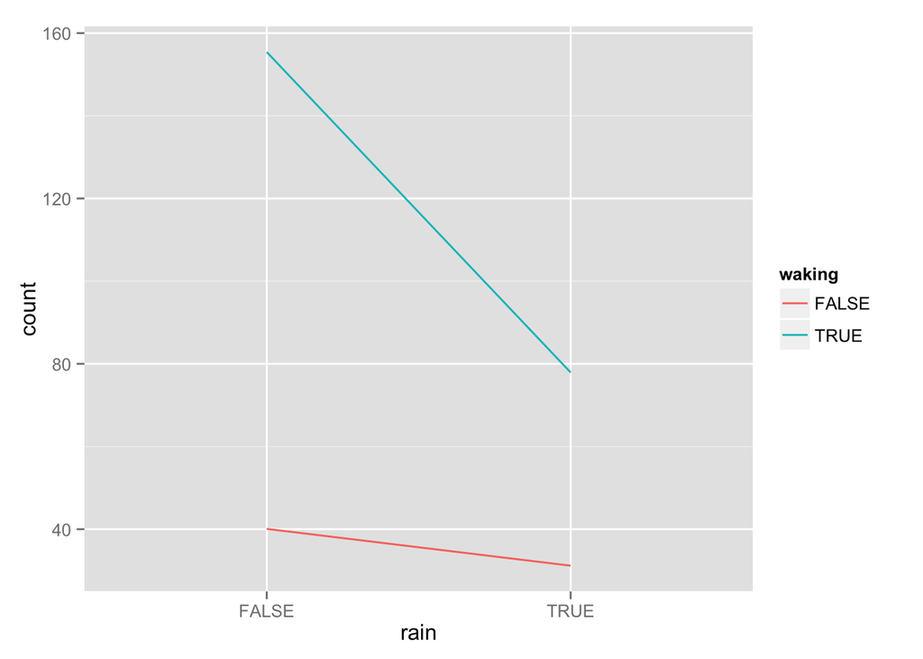

```r
by.rain = ddply(core, c('rain','waking'), summarize,
                   count = mean(count))

ggplot(data=by.rain, aes(x=rain, y=count, group=waking, color=waking)) +
  geom_line()
```

During waking hours, the effect of rain on post count is much more pronounced. This makes sense: people awake late in the night are more likely to be posting indoors, and so should be less affected by rain.

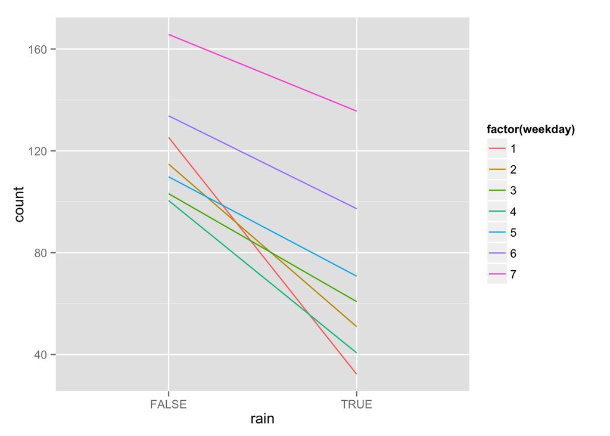

```r
by.weekday = ddply(core, c('weekday','rain'), summarize,
                   count = mean(count))

ggplot(data=by.weekday, aes(x=rain, y=count, group=factor(weekday), color=factor(weekday))) +
  geom_line()
```

Here, the steeper the slope, the bigger the effect of rain, so we see that Monday, Tuesday, and Thursday see a bigger effect of rain on posting volume, while the intrepid weekenders don’t mind the rain as much. The difference between Monday and the weekend is pretty big: perhaps the addition of rain to an already dampened Monday spirit really kills the desire to post to Instagram.

## Sky

Recall that very cloudy skies mean lower post volume. Let’s do what we’ve been doing, and consider potential confounds. Sky, like rain, shouldn’t correlate with hour and weekday, but let’s take a look:

```r
CrossTable(core$hour,core$sky,expected=1)
```

```
##
##
##    Cell Contents
## |-------------------------|
## |                       N |
## |              Expected N |
## | Chi-square contribution |
## |           N / Row Total |
## |           N / Col Total |
## |         N / Table Total |
## |-------------------------|
##
##
## Total Observations in Table:  4488
##
##
##              | core$sky
##    core$hour |         0 |    0.1875 |    0.4375 |      0.75 |         1 | Row Total |
## -------------|-----------|-----------|-----------|-----------|-----------|-----------|
##            0 |        86 |         6 |         7 |        18 |        76 |       193 |
##              |    77.277 |    10.063 |     9.461 |    20.427 |    75.772 |           |
##              |     0.985 |     1.640 |     0.640 |     0.288 |     0.001 |           |
##              |     0.446 |     0.031 |     0.036 |     0.093 |     0.394 |     0.043 |
##              |     0.048 |     0.026 |     0.032 |     0.038 |     0.043 |           |
##              |     0.019 |     0.001 |     0.002 |     0.004 |     0.017 |           |
## -------------|-----------|-----------|-----------|-----------|-----------|-----------|
##            1 |        78 |         4 |        10 |        26 |        80 |       198 |
##              |    79.279 |    10.324 |     9.706 |    20.956 |    77.735 |           |
##              |     0.021 |     3.873 |     0.009 |     1.214 |     0.066 |           |
##              |     0.394 |     0.020 |     0.051 |     0.131 |     0.404 |     0.044 |
##              |     0.043 |     0.017 |     0.045 |     0.055 |     0.045 |           |
##              |     0.017 |     0.001 |     0.002 |     0.006 |     0.018 |           |
## -------------|-----------|-----------|-----------|-----------|-----------|-----------|
##            2 |        77 |        11 |         1 |        22 |        81 |       192 |
##              |    76.877 |    10.011 |     9.412 |    20.321 |    75.380 |           |
##              |     0.000 |     0.098 |     7.518 |     0.139 |     0.419 |           |
##              |     0.401 |     0.057 |     0.005 |     0.115 |     0.422 |     0.043 |
##              |     0.043 |     0.047 |     0.005 |     0.046 |     0.046 |           |
##              |     0.017 |     0.002 |     0.000 |     0.005 |     0.018 |           |
## -------------|-----------|-----------|-----------|-----------|-----------|-----------|
```

[output cut: 146 more lines]

```
## -------------|-----------|-----------|-----------|-----------|-----------|-----------|
## Column Total |      1797 |       234 |       220 |       475 |      1762 |      4488 |
##              |     0.400 |     0.052 |     0.049 |     0.106 |     0.393 |           |
## -------------|-----------|-----------|-----------|-----------|-----------|-----------|
##
##
## Statistics for All Table Factors
##
##
## Pearson's Chi-squared test
## ------------------------------------------------------------
## Chi^2 =  186.2062     d.f. =  92     p =  2.346466e-08
##
##
##
```

```r
CrossTable(core$weekday,core$sky,expected=1)
```

```
##
##
##    Cell Contents
## |-------------------------|
## |                       N |
## |              Expected N |
## | Chi-square contribution |
## |           N / Row Total |
## |           N / Col Total |
## |         N / Table Total |
## |-------------------------|
##
##
## Total Observations in Table:  4488
##
##
##              | core$sky
## core$weekday |         0 |    0.1875 |    0.4375 |      0.75 |         1 | Row Total |
## -------------|-----------|-----------|-----------|-----------|-----------|-----------|
##            1 |       297 |        24 |        19 |        47 |       209 |       596 |
##              |   238.639 |    31.075 |    29.216 |    63.079 |   233.991 |           |
##              |    14.273 |     1.611 |     3.572 |     4.099 |     2.669 |           |
##              |     0.498 |     0.040 |     0.032 |     0.079 |     0.351 |     0.133 |
##              |     0.165 |     0.103 |     0.086 |     0.099 |     0.119 |           |
##              |     0.066 |     0.005 |     0.004 |     0.010 |     0.047 |           |
## -------------|-----------|-----------|-----------|-----------|-----------|-----------|
##            2 |       294 |        33 |        37 |        68 |       199 |       631 |
##              |   252.653 |    32.900 |    30.931 |    66.784 |   247.732 |           |
##              |     6.766 |     0.000 |     1.191 |     0.022 |     9.586 |           |
##              |     0.466 |     0.052 |     0.059 |     0.108 |     0.315 |     0.141 |
##              |     0.164 |     0.141 |     0.168 |     0.143 |     0.113 |           |
##              |     0.066 |     0.007 |     0.008 |     0.015 |     0.044 |           |
## -------------|-----------|-----------|-----------|-----------|-----------|-----------|
##            3 |       211 |        33 |        27 |        82 |       344 |       697 |
##              |   279.080 |    36.341 |    34.167 |    73.769 |   273.644 |           |
##              |    16.608 |     0.307 |     1.503 |     0.918 |    18.089 |           |
##              |     0.303 |     0.047 |     0.039 |     0.118 |     0.494 |     0.155 |
##              |     0.117 |     0.141 |     0.123 |     0.173 |     0.195 |           |
##              |     0.047 |     0.007 |     0.006 |     0.018 |     0.077 |           |
## -------------|-----------|-----------|-----------|-----------|-----------|-----------|
```

[output cut: 27 more lines]

```
## -------------|-----------|-----------|-----------|-----------|-----------|-----------|
## Column Total |      1797 |       234 |       220 |       475 |      1762 |      4488 |
##              |     0.400 |     0.052 |     0.049 |     0.106 |     0.393 |           |
## -------------|-----------|-----------|-----------|-----------|-----------|-----------|
##
##
## Statistics for All Table Factors
##
##
## Pearson's Chi-squared test
## ------------------------------------------------------------
## Chi^2 =  253.3037     d.f. =  24     p =  3.651618e-40
##
##
##
```

Ok, weird, sky is actually correlated with both of these. I suppose we could have expected this, because we found that it rains less on Sunday than on other days (in our data, anyway). This is sort of a meaningless correlation, but we now need to control for hour and weekday in our model.

```r
m0 = glm.nb(data=core,count~factor(hour)+factor(weekday))
m1 = glm.nb(data=core,count~factor(hour)+factor(weekday)+sky)
anova(m0,m1)
```

```
## Likelihood ratio tests of Negative Binomial Models
##
## Response: count
##                                  Model    theta Resid. df    2 x log-lik.
## 1       factor(hour) + factor(weekday) 2.494774      4458       -47133.29
## 2 factor(hour) + factor(weekday) + sky 3.051115      4457       -46231.24
##     Test    df LR stat. Pr(Chi)
## 1
## 2 1 vs 2     1 902.0488       0
```

Sky is a significant regressor over and above hour and weekday. A note here: in the model above, I’m treating sky as a linear axis instead of a factor, because it truly is a linear variable (% cloud cover). For some purposes, like plotting, it’s better to have R treat it as a factor, and we may switch between sometimes.

What about the other temporal variables? (I’ll consider hour and weekday again because I’m looking for interactions, too)

```r
summary(glm.nb(data=core,count~factor(month)*sky))
```

```
##
## Call:
## glm.nb(formula = count ~ factor(month) * sky, data = core, init.theta = 1.098013048,
##     link = log)
##
## Deviance Residuals:
##     Min       1Q   Median       3Q      Max
## -2.6997  -1.1111  -0.2236   0.4057   2.8256
##
## Coefficients:
##                     Estimate Std. Error z value Pr(>|z|)
## (Intercept)         4.604896   0.139049  33.117  < 2e-16 ***
## factor(month)3      0.400599   0.148113   2.705 0.006837 **
## factor(month)4      0.497040   0.146182   3.400 0.000674 ***
## factor(month)5      0.599980   0.148950   4.028 5.62e-05 ***
## factor(month)6      0.557784   0.146626   3.804 0.000142 ***
## factor(month)7      0.387528   0.146793   2.640 0.008292 **
## factor(month)8      0.257723   0.259986   0.991 0.321542
## sky                -0.507947   0.245937  -2.065 0.038889 *
## factor(month)3:sky  0.004395   0.255998   0.017 0.986302
## factor(month)4:sky -0.179340   0.255164  -0.703 0.482155
## factor(month)5:sky -0.229920   0.255719  -0.899 0.368593
## factor(month)6:sky -0.512887   0.255948  -2.004 0.045084 *
## factor(month)7:sky -0.292565   0.259206  -1.129 0.259027
## factor(month)8:sky -0.499180   0.376884  -1.324 0.185339
## ---
## Signif. codes:  0 '***' 0.001 '**' 0.01 '*' 0.05 '.' 0.1 ' ' 1
##
## (Dispersion parameter for Negative Binomial(1.098) family taken to be 1)
##
##     Null deviance: 5669.9  on 4487  degrees of freedom
## Residual deviance: 5100.1  on 4474  degrees of freedom
## AIC: 51297
##
## Number of Fisher Scoring iterations: 1
##
##
##               Theta:  1.0980
##           Std. Err.:  0.0212
##
##  2 x log-likelihood:  -51266.5160
```

```r
summary(glm.nb(data=core,count~summer*sky))
```

```
##
## Call:
## glm.nb(formula = count ~ summer * sky, data = core, init.theta = 1.091083591,
##     link = log)
##
## Deviance Residuals:
##     Min       1Q   Median       3Q      Max
## -2.6732  -1.1075  -0.2398   0.3983   2.7862
##
## Coefficients:
##                 Estimate Std. Error z value Pr(>|z|)
## (Intercept)     5.086994   0.028057 181.307  < 2e-16 ***
## summerTRUE     -0.008335   0.043146  -0.193    0.847
## sky            -0.627111   0.039361 -15.932  < 2e-16 ***
## summerTRUE:sky -0.308964   0.065533  -4.715 2.42e-06 ***
## ---
## Signif. codes:  0 '***' 0.001 '**' 0.01 '*' 0.05 '.' 0.1 ' ' 1
##
## (Dispersion parameter for Negative Binomial(1.0911) family taken to be 1)
##
##     Null deviance: 5635.1  on 4487  degrees of freedom
## Residual deviance: 5103.2  on 4484  degrees of freedom
## AIC: 51311
##
## Number of Fisher Scoring iterations: 1
##
##
##               Theta:  1.0911
##           Std. Err.:  0.0210
##
##  2 x log-likelihood:  -51300.9540
```

```r
summary(glm.nb(data=core,count~daylight*sky))
```

```
##
## Call:
## glm.nb(formula = count ~ daylight * sky, data = core, init.theta = 1.27018371,
##     link = log)
##
## Deviance Residuals:
##     Min       1Q   Median       3Q      Max
## -2.8922  -1.0615  -0.2927   0.4054   3.7932
##
## Coefficients:
##                  Estimate Std. Error z value Pr(>|z|)
## (Intercept)       4.64865    0.02707 171.702   <2e-16 ***
## daylightTRUE      0.74455    0.03962  18.793   <2e-16 ***
## sky              -0.80236    0.03946 -20.335   <2e-16 ***
## daylightTRUE:sky  0.14748    0.05843   2.524   0.0116 *
## ---
## Signif. codes:  0 '***' 0.001 '**' 0.01 '*' 0.05 '.' 0.1 ' ' 1
##
## (Dispersion parameter for Negative Binomial(1.2702) family taken to be 1)
##
##     Null deviance: 6530.4  on 4487  degrees of freedom
## Residual deviance: 5034.7  on 4484  degrees of freedom
## AIC: 50498
##
## Number of Fisher Scoring iterations: 1
##
##
##               Theta:  1.2702
##           Std. Err.:  0.0250
##
##  2 x log-likelihood:  -50487.9650
```

```r
summary(glm.nb(data=core,count~waking*sky))
```

```
##
## Call:
## glm.nb(formula = count ~ waking * sky, data = core, init.theta = 1.494978246,
##     link = log)
##
## Deviance Residuals:
##     Min       1Q   Median       3Q      Max
## -3.1395  -1.0132  -0.2554   0.3957   4.2697
##
## Coefficients:
##                Estimate Std. Error z value Pr(>|z|)
## (Intercept)     3.97561    0.03326 119.524   <2e-16 ***
## wakingTRUE      1.34767    0.03979  33.868   <2e-16 ***
## sky            -0.66830    0.04802 -13.918   <2e-16 ***
## wakingTRUE:sky -0.02679    0.05797  -0.462    0.644
## ---
## Signif. codes:  0 '***' 0.001 '**' 0.01 '*' 0.05 '.' 0.1 ' ' 1
##
## (Dispersion parameter for Negative Binomial(1.495) family taken to be 1)
##
##     Null deviance: 7643.4  on 4487  degrees of freedom
## Residual deviance: 4970.6  on 4484  degrees of freedom
## AIC: 49653
##
## Number of Fisher Scoring iterations: 1
##
##
##               Theta:  1.4950
##           Std. Err.:  0.0300
##
##  2 x log-likelihood:  -49643.0260
```

```r
summary(glm.nb(data=core,count~high.volume.hours*sky))
```

```
##
## Call:
## glm.nb(formula = count ~ high.volume.hours * sky, data = core,
##     init.theta = 1.608764852, link = log)
##
## Deviance Residuals:
##     Min       1Q   Median       3Q      Max
## -3.2405  -0.9891  -0.2354   0.4207   5.3191
##
## Coefficients:
##                            Estimate Std. Error z value Pr(>|z|)
## (Intercept)                4.237002   0.025609  165.45   <2e-16 ***
## high.volume.hoursTRUE      1.240996   0.035269   35.19   <2e-16 ***
## sky                       -0.685463   0.037102  -18.48   <2e-16 ***
## high.volume.hoursTRUE:sky  0.004679   0.051927    0.09    0.928
## ---
## Signif. codes:  0 '***' 0.001 '**' 0.01 '*' 0.05 '.' 0.1 ' ' 1
##
## (Dispersion parameter for Negative Binomial(1.6088) family taken to be 1)
##
##     Null deviance: 8202.4  on 4487  degrees of freedom
## Residual deviance: 4956.4  on 4484  degrees of freedom
## AIC: 49293
##
## Number of Fisher Scoring iterations: 1
##
##
##               Theta:  1.6088
##           Std. Err.:  0.0327
##
##  2 x log-likelihood:  -49282.8220
```

```r
summary(glm.nb(data=core,count~peak.hours*sky))
```

```
##
## Call:
## glm.nb(formula = count ~ peak.hours * sky, data = core, init.theta = 1.363380654,
##     link = log)
##
## Deviance Residuals:
##     Min       1Q   Median       3Q      Max
## -3.0789  -1.0611  -0.1990   0.4224   3.8273
##
## Coefficients:
##                    Estimate Std. Error z value Pr(>|z|)
## (Intercept)         4.67024    0.02293 203.679   <2e-16 ***
## peak.hoursTRUE      0.95235    0.04138  23.017   <2e-16 ***
## sky                -0.74141    0.03359 -22.071   <2e-16 ***
## peak.hoursTRUE:sky  0.06975    0.06135   1.137    0.256
## ---
## Signif. codes:  0 '***' 0.001 '**' 0.01 '*' 0.05 '.' 0.1 ' ' 1
##
## (Dispersion parameter for Negative Binomial(1.3634) family taken to be 1)
##
##     Null deviance: 6993.2  on 4487  degrees of freedom
## Residual deviance: 5010.0  on 4484  degrees of freedom
## AIC: 50132
##
## Number of Fisher Scoring iterations: 1
##
##
##               Theta:  1.3634
##           Std. Err.:  0.0271
##
##  2 x log-likelihood:  -50121.8920
```

```r
summary(glm.nb(data=core,count~factor(weekday)*sky))
```

```
##
## Call:
## glm.nb(formula = count ~ factor(weekday) * sky, data = core,
##     init.theta = 1.099460951, link = log)
##
## Deviance Residuals:
##     Min       1Q   Median       3Q      Max
## -2.7515  -1.1193  -0.2159   0.4118   2.6538
##
## Coefficients:
##                      Estimate Std. Error z value Pr(>|z|)
## (Intercept)           5.09383    0.05345  95.301  < 2e-16 ***
## factor(weekday)2     -0.15047    0.07514  -2.003 0.045212 *
## factor(weekday)3     -0.10658    0.08127  -1.311 0.189706
## factor(weekday)4     -0.10093    0.08065  -1.251 0.210766
## factor(weekday)5     -0.03649    0.08103  -0.450 0.652481
## factor(weekday)6      0.04820    0.07645   0.631 0.528360
## factor(weekday)7      0.12372    0.07473   1.656 0.097806 .
## sky                  -0.85739    0.08445 -10.153  < 2e-16 ***
## factor(weekday)2:sky  0.27237    0.11967   2.276 0.022845 *
## factor(weekday)3:sky  0.15750    0.11721   1.344 0.179027
## factor(weekday)4:sky  0.08179    0.11689   0.700 0.484095
## factor(weekday)5:sky  0.13896    0.11729   1.185 0.236100
## factor(weekday)6:sky  0.21304    0.11985   1.778 0.075477 .
## factor(weekday)7:sky  0.48259    0.12949   3.727 0.000194 ***
## ---
## Signif. codes:  0 '***' 0.001 '**' 0.01 '*' 0.05 '.' 0.1 ' ' 1
##
## (Dispersion parameter for Negative Binomial(1.0995) family taken to be 1)
##
##     Null deviance: 5677.1  on 4487  degrees of freedom
## Residual deviance: 5099.7  on 4474  degrees of freedom
## AIC: 51290
##
## Number of Fisher Scoring iterations: 1
##
##
##               Theta:  1.0995
##           Std. Err.:  0.0212
##
##  2 x log-likelihood:  -51259.5160
```

```r
summary(glm.nb(data=core,count~factor(hour)*sky))
```

```
##
## Call:
## glm.nb(formula = count ~ factor(hour) * sky, data = core, init.theta = 2.972074019,
##     link = log)
##
## Deviance Residuals:
##     Min       1Q   Median       3Q      Max
## -4.3492  -0.7464  -0.1493   0.4299   4.1495
##
## Coefficients:
##                     Estimate Std. Error z value Pr(>|z|)
## (Intercept)         4.522176   0.061167  73.932  < 2e-16 ***
## factor(hour)1      -0.545588   0.089084  -6.124 9.10e-10 ***
## factor(hour)2      -1.162844   0.089926 -12.931  < 2e-16 ***
## factor(hour)3      -1.701641   0.090483 -18.806  < 2e-16 ***
## factor(hour)4      -1.940359   0.091900 -21.114  < 2e-16 ***
## factor(hour)5      -1.630251   0.091582 -17.801  < 2e-16 ***
## factor(hour)6      -0.818378   0.087951  -9.305  < 2e-16 ***
## factor(hour)7      -0.055710   0.089397  -0.623  0.53317
## factor(hour)8       0.258940   0.088127   2.938  0.00330 **
## factor(hour)9       0.409167   0.086972   4.705 2.54e-06 ***
## factor(hour)10      0.618206   0.088426   6.991 2.73e-12 ***
## factor(hour)11      0.734328   0.090347   8.128 4.37e-16 ***
## factor(hour)12      0.969690   0.093004  10.426  < 2e-16 ***
## factor(hour)13      1.030666   0.094986  10.851  < 2e-16 ***
## factor(hour)14      1.128614   0.090471  12.475  < 2e-16 ***
## factor(hour)15      1.176416   0.090050  13.064  < 2e-16 ***
## factor(hour)16      1.227319   0.091896  13.355  < 2e-16 ***
## factor(hour)17      1.201511   0.089044  13.493  < 2e-16 ***
## factor(hour)18      1.029764   0.087937  11.710  < 2e-16 ***
## factor(hour)19      0.984438   0.085843  11.468  < 2e-16 ***
## factor(hour)20      0.825880   0.086008   9.602  < 2e-16 ***
## factor(hour)21      0.744168   0.085623   8.691  < 2e-16 ***
## factor(hour)22      0.575489   0.086298   6.669 2.58e-11 ***
## factor(hour)23      0.409020   0.085426   4.788 1.68e-06 ***
## sky                -0.599243   0.091305  -6.563 5.27e-11 ***
## factor(hour)1:sky   0.073916   0.130611   0.566  0.57145
## factor(hour)2:sky   0.073850   0.132175   0.559  0.57635
## factor(hour)3:sky   0.171459   0.132034   1.299  0.19408
## factor(hour)4:sky  -0.026608   0.135843  -0.196  0.84471
```

[output cut: 20 more lines]

```
## Signif. codes:  0 '***' 0.001 '**' 0.01 '*' 0.05 '.' 0.1 ' ' 1
##
## (Dispersion parameter for Negative Binomial(2.9721) family taken to be 1)
##
##     Null deviance: 14690.9  on 4487  degrees of freedom
## Residual deviance:  4796.9  on 4440  degrees of freedom
## AIC: 46449
##
## Number of Fisher Scoring iterations: 1
##
##
##               Theta:  2.9721
##           Std. Err.:  0.0651
##
##  2 x log-likelihood:  -46350.7680
```

Sky is a significant regressor in all these models. The interpretation of the p-values here is that they answer the question whether some particular regressor (sky, for us) is significant in a model that already includes all the others. With temperature and rain, I was a little more perspicacious in my hunt for significance and interactions, but here I’m sort of lumping everything together for efficiency.

The interesting variables seem to be month, summer, and weekday. There’s a bit of a daylight thing happening, too, though that’s to be expected.

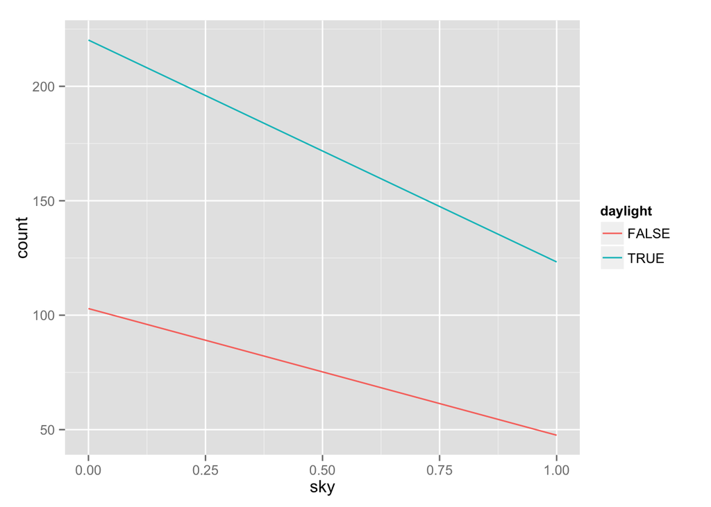

```r
by.sky = ddply(core, c('sky','daylight'), summarize,
                   count = mean(count))

ggplot(data=by.sky, aes(x=sky, y=count, group=daylight, color=daylight)) +
  stat_smooth(method=lm,se=F)
```

As expected, the dampening effect of cloudiness on post volume is less pronounced when it’s dark out. In fact, it’s surprising that the difference isn’t bigger. Maybe people are more inclined to snap nighttime photos when it’s clear, to capture starry skies (or perhaps the moon)?

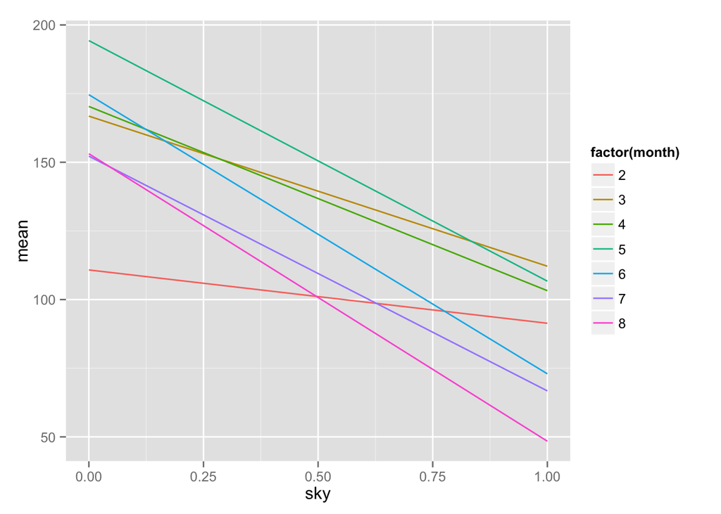

```r
by.sky = ddply(core, c('sky','month'), summarize,
                   mean = mean(count))

ggplot(data=by.sky, aes(x=sky, y=mean, group=factor(month), color=factor(month))) +
  stat_smooth(method=lm,se=F)
```

The effect of sky on post volume is bigger in the summer months. Perhaps people expect clear skies in summer, and when they don’t get them, they give up on IG. Or what amounts to the same, perhaps people like to snap outdoor photos that ‘fit the season’, and so they are okay taking pictures with cloudy skies in spring but not summer. In any case, post volume *really* drops off on overcast summer days.

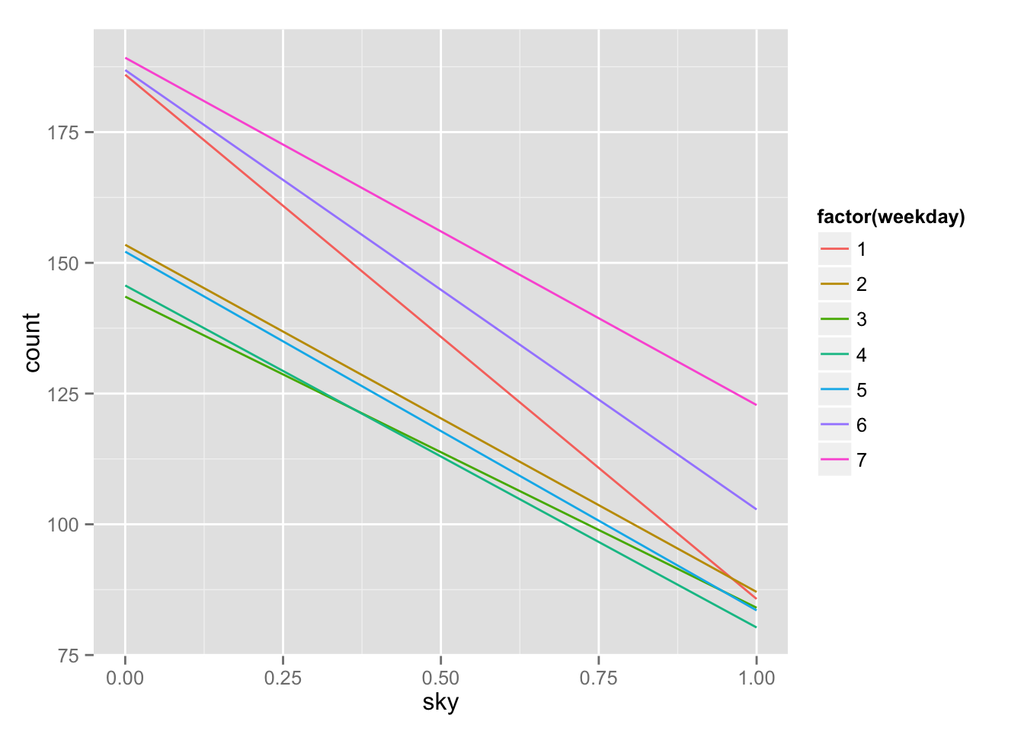

```r
by.sky = ddply(core, c('sky','weekday'), summarize,
                   count = mean(count))

ggplot(data=by.sky, aes(x=sky, y=count, group=factor(weekday), color=factor(weekday))) +
  stat_smooth(method=lm,se=F)
```

We saw this effect with rain: rainy and/or cloudy Mondays really drive down IG posting. The effect is less impressive with sky, but it’s there.

Finally, we can control for other weather variables:

```r
m0 = glm.nb(data=core,count~temp+rain)
m1 = glm.nb(data=core,count~temp+rain+sky)
anova(m0,m1)
```

```
## Likelihood ratio tests of Negative Binomial Models
##
## Response: count
##               Model    theta Resid. df    2 x log-lik.   Test    df
## 1       temp + rain 1.033953      4485       -51596.19
## 2 temp + rain + sky 1.103632      4484       -51239.28 1 vs 2     1
##   LR stat. Pr(Chi)
## 1
## 2 356.9085       0
```

Sky remains a significant regressor even after accounting for temperature and rain.

## Final coefficient estimates

```r
m = glm.nb(data=core,count~factor(hour)+factor(weekday)+factor(month)+sky+temp+rain+wind)
exp(m$coef)
```

```
##      (Intercept)    factor(hour)1    factor(hour)2    factor(hour)3
##       50.1400750        0.5929658        0.3170989        0.1975168
##    factor(hour)4    factor(hour)5    factor(hour)6    factor(hour)7
##        0.1418405        0.1809149        0.4068206        0.9072275
##    factor(hour)8    factor(hour)9   factor(hour)10   factor(hour)11
##        1.1890758        1.4027360        1.6629150        1.8440222
##   factor(hour)12   factor(hour)13   factor(hour)14   factor(hour)15
##        2.3703003        2.5058123        2.9406761        3.0038932
##   factor(hour)16   factor(hour)17   factor(hour)18   factor(hour)19
##        2.8546234        2.4623506        2.4863482        2.3111718
##   factor(hour)20   factor(hour)21   factor(hour)22   factor(hour)23
##        2.0100876        1.8851217        1.5647280        1.4700967
## factor(weekday)2 factor(weekday)3 factor(weekday)4 factor(weekday)5
##        0.9474015        0.9883342        0.9709154        1.1222789
## factor(weekday)6 factor(weekday)7   factor(month)3   factor(month)4
##        1.1353779        1.3221388        1.2365019        1.0912366
##   factor(month)5   factor(month)6   factor(month)7   factor(month)8
##        1.0659863        0.9049946        0.7919807        0.6400527
##              sky             temp         rainTRUE             wind
##        0.5390504        1.0096531        0.7282802        1.0095927
```

```r
exp(m$coef*20)
```

```
##      (Intercept)    factor(hour)1    factor(hour)2    factor(hour)3
##     1.008555e+34     2.887973e-05     1.056561e-10     8.167344e-15
##    factor(hour)4    factor(hour)5    factor(hour)6    factor(hour)7
##     1.086438e-17     1.410866e-15     1.541906e-08     1.426673e-01
##    factor(hour)8    factor(hour)9   factor(hour)10   factor(hour)11
##     3.192939e+01     8.699993e+02     2.614576e+04     2.066917e+05
##   factor(hour)12   factor(hour)13   factor(hour)14   factor(hour)15
##     3.133772e+07     9.527320e+07     2.338534e+09     3.578408e+09
##   factor(hour)16   factor(hour)17   factor(hour)18   factor(hour)19
##     1.291149e+09     6.714256e+07     8.151526e+07     1.890796e+07
##   factor(hour)20   factor(hour)21   factor(hour)22   factor(hour)23
##     1.159577e+06     3.212091e+05     7.740647e+03     2.222891e+03
## factor(weekday)2 factor(weekday)3 factor(weekday)4 factor(weekday)5
##     3.393765e-01     7.908180e-01     5.541508e-01     1.004652e+01
## factor(weekday)6 factor(weekday)7   factor(month)3   factor(month)4
##     1.267094e+01     2.664042e+02     6.980648e+01     5.732958e+00
##   factor(month)5   factor(month)6   factor(month)7   factor(month)8
##     3.589487e+00     1.358062e-01     9.425237e-03     1.331418e-04
##              sky             temp         rainTRUE             wind
##     4.291291e-06     1.211835e+00     1.761855e-03     1.210387e+00
```